# Lab One Resubmission: Visualization and Data Preprocessing

## MSDS 7331: Data Mining

## Group 3: Shanqing Gu, Manisha Pednekar, Dmitry Andreev and Jonathan Knowles

*Analysis of Online News Popularity Dataset (https://archive.ics.uci.edu/ml/datasets/Online+News+Popularity ): explore the statistical summaries of the features, visualize the attributes, and make conclusions from the visualizations and analysis*

## Resubmission Outlines:

#### Section 1: Business Understanding (7/10)

Section 1 Corrections

JD comments: You will also perform 10-fold cross-validataion to measure effectiveness as well. 73% is a low accuracy for this. Where id you come up with this number? Missing supporting explanation

Group 3 corrections:

(1). The discrimination power of 73% was the best result provided by a Random Forest model (Ref 2: Kelwin Fernandes, Pedro Vinagre, and Paulo Cortez. A Proactive Intelligent Decision Support System for Predicting the Popularity of Online News.

(2). We run different models in Exceptional Work Section 9 and get the highest prediction accuracy at 66%, coming close to the literature reported 73% acuracy. We are planning to use more techniques from the MSDS 7331 - Data Mining class to improve upon our model accuracy. One such technique includes performing 10-fold cross-validation to measure the effectiveness of our predictions.

#### Section 4: Simple Statistics (7/10)

Section 4 Corrections

JD comments: Code error and missing images in this section

Group 3 corrections:

Have removed the confusing codes and add corresponding descriptions in this section.

#### Section 6: Explore Joint Realtionships (7/15)

Section 6 Corrections

JD comments: Pair plots are too small to read. Perform on a subset of attributes in the future. Section analysis is not complete with note to group. "Need to mention..."

Group 3 corrections:

In this section, we have accomplished:

06_01 Correlation heatmap to visualize relationships between attributes

06_02 Subset of highly correlated attributes

06_03 Larger subset of highly correlated attributes

06_04 Pairplot for LDA cluster (LDA_01, LDA_02, LDA-03), as grouped by Weekday and Channel

06_05 Pairplot for Polarity cluster as grouped by Weekday and Channel

06_06 Pairplot for Polarity cluster as grouped by Weekday and Channel

06_07 Pairplot for variables num_imgs and num_videos, as grouped by Weekday and Channel

#### Section 7: Explore Attributes and Classes (2/10)

Section 7 Corrections

JD comments:

This section is to "Identify and explain interesting relationships between features and the class you are trying to predict (i.e. relationships with variables and the target classification)." You need to explain relationships between the feature "popular" or" shares" and other columns in your dataset.

Group 3 corrections:

In this section, we have accomplished:

07_01 Target Class Variable - Online News Article Popularity

07_02 Title Sentiment Polarity

07_03 Title Subjectivity

07_04 Number of Embedded Hyperlinks and Associated Social Media Shares

07_05 Number of Videos and Images

07_06 Summary showing relationship of attributes with target variable

#### Section 9: Exceptional (5/10)

Section 9 Corrections

JD comments: Missing any real analysis of your charts and PCA.

Group 3 corrections:

For this section, remove our previous PCA analysis and follow the workflow below to create a prediction model:

09_01 Use Recursive Feature Elimination (RFE) for Feature Selection

09_02 Feature selection with Linear Model (LM) and Random Forest(RF)

09_02_01 Linear Model (LM) Feature Ranking

09_02_02 Random Forest (RF) feature ranking

09_02_03 Rank and plot the feature with the mean values calculated from all the scores from RFE, LM and RF

09_03 Compare prediction model accuracy

09_03_01 Logistic regression without considering individual variable weight (model accuracy = 0.57)

09_03_02 Logistic regression with considering individual variable weight (model accuracy = 0.64)

09_03_03 Support Vector Mechine (SVM) method (model accuracy = 0.66)¶

1. Business Understanding
2. Data Mining Type
3. Data Quality
4. Simple Statistics
5. Visualize Attributes
6. Explore Joint Relationships
7. Explore Attributes and Class
8. New Features
9. Exceptional Work

### 01. Business Understanding

Back to top

#### Section Objective:

Describe the purpose of the dataset you selected (i.e., why was this data collected in the first place?). Describe how you would define and measure the outcomes from the dataset. That is, why is this data important and how do you know if you have mined useful knowledge from the dataset? How would you measure the effectiveness of a good prediction algorithm? Be specific *

##### Purpose of this dataset

This Online News Popularity Dataset was acquisited from [Mashable](https://mashable.com), a popular news and opinion website that focuses on social media and technology.

The dataset is available for download at the [UCI Machine Learning Repository](https://archive.ics.uci.edu/ml/datasets/Online+News+Popularity)

The data consists of 39,644 records with 61 attributes that provide details and meta-data about online news articles that were published by Mashable over a two year period ranging 2013 - 2015. The goal of collecting this data was to predict the popularity of a news article. Popularity in this case is defined as the number of times that the article is shared across all social media platforms.

##### Defining and measuring outcomes of this dataset

Our group would like to create a classification model that can determine if an article will be popular based on the amount of times it is shared on social media. We have determined that an article can be classified as popular if it is shared 1,400 number of times. The model will have a binary output: popular / not popular.

We chose not to predict the actual number of shares that an article will have once published since that would require complex machine learning algorithms that are outside the scope of this lab assignment. In addition, if the accuracy of the prediction model is low then it could potentially provide publishers with false hope such as predicting that their article will have 1,000 shares but in reality it only yields 10 shares. Whereas the binary output doesn't promise something unrealistic but simply tells the author whether the article surpasses the chosen cutoff value of 1,400 shares.

##### Why is this data important?

This data is important because it can be used to help Mashable and other online publishers understand the factors that play a part in how popular their articles are. With a reliable model for predicting popularity Mashable will understand how they can design articles to achieve maximum popularity and exposure, which is the key objective of any publishing company.

###### How will we measure the effectiveness of our alogrithm?

We will measure the effectiveness of our algorithm by the accuracy of its classification. We would like to build a model that can achieve higher prediction accuracy than previous study as carried out by K. Fernandes et al. (Reference 2, with prediction accuracy at 73%).

(1). The discrimination power of 73% was the best result provided by a Random Forest model (Ref 2: Kelwin Fernandes, Pedro Vinagre, and Paulo Cortez. A Proactive Intelligent Decision Support System for Predicting the Popularity of Online News.

(2). We run different models in Exceptional Work Section 9 and get the highest prediction accuracy at 66%, coming close to the literature reported 73% acuracy. We are planning to use more techniques from the MSDS 7331 - Data Mining class to improve upon our model accuracy. One such technique includes performing 10-fold cross-validation to measure the effectiveness of our predictions. Back to Resubmission Corrections

##### Importing Python Libraries

To keep this Jupyter notebook organized, we decided to import the necessary Python libraries all together at the beginning rather than doing so separately as we move through each section. The following libraries will be used for this lab assignment:

- pandas for data manipulation
- numpy for multidimensional array computing
- matplotlib.pyplot and Seaborn for data visualization
- %matplotlib inline to include plots within the notebook
- sns.set_style to apply the same theme for plots throughtout notebook

```python
# Import general libraries which will be uses for this Lab_01 project
import pandas as pd
import numpy as np
import matplotlib.pyplot as plt
import seaborn as sns
%matplotlib inline

# Change deault Seaborn plot style to "whitegrid"
sns.set_style("whitegrid")
```

### 02. Data Mining Type

Back to top

#### Section Objective:

Describe the meaning and type of data (scale, values, etc.) for each attribute in the data file.

#### Removing non-predictive Attributes

In the code below we import the data set starting with the 3rd variable as the first two variables were non-predictive and will not help in our analysis.

Those variables were:

1. URL - actual url of the article
2. Timedelta - amount of time from when the article was posted to when data was collected

```python
# Read csv file
df = pd.read_csv("OnlineNewsPopularity.csv")

# Exclude url and timedelta columns, read from n_tokens_title
df = df.loc[:, ' n_tokens_title':]

dfCopy = df.copy() # dfCopy.info() # use df.tail() to check
```

#### Data Description

The code below generates a table of the variables remaining in the dataset. For each attribute we list:

1. Variable name
2. Type of data
3. Scale(min, mean, median and max)
4. Description.

```python
from IPython.display import display, HTML

variables_description = [
[' n_tokens_title', 'ratio', 'TBD', 'Number of words in the title']
,[' n_tokens_content', 'ratio', 'TBD', 'Number of words in the content 0-8500 ']
,[' n_unique_tokens', 'ratio', 'TBD', 'Rate of unique words in the content']
,[' n_non_stop_words', 'ratio', 'TBD', 'Rate of non-stop words in the content']
,[' n_non_stop_unique_tokens', 'ratio', 'TBD', 'Rate of unique non-stop words in the content']
,[' num_hrefs', 'ratio', 'TBD', 'Number of links']
,[' num_self_hrefs', 'ratio', 'TBD', 'Number of links to other articles published by Mashable']
,[' num_imgs', 'ratio', 'TBD', 'Number of images']
,[' num_videos', 'ratio', 'TBD', 'Number of videos']
,[' average_token_length', 'ratio', 'TBD', '(Binary) Average length of the words in the content']
,[' num_keywords', 'ratio', 'TBD', '(Binary) Number of keywords in the metadata']
,[' data_channel_is_lifestyle', 'nominal', 'TBD', '(Binary) Is data channel Lifestyle?']
,[' data_channel_is_entertainment', 'nominal', 'TBD', '(Binary) Is data channel Entertainment?']
,[' data_channel_is_bus', 'nominal', 'TBD', '(Binary) Is data channel Business?']
,[' data_channel_is_socmed', 'nominal', 'TBD', '(Binary) Is data channel Social Media? ']
,[' data_channel_is_tech', 'nominal', 'TBD', '(Binary) Is data channel Tech?']
,[' data_channel_is_world', 'nominal', 'TBD', '(Binary) Is data channel World?']
,[' kw_min_min', 'ratio', 'TBD', 'Worst keyword (min. shares)']
,[' kw_max_min', 'ratio', 'TBD', 'Worst keyword (max. shares)']
,[' kw_avg_min', 'ratio', 'TBD', 'Worst keyword (avg. shares)']
,[' kw_min_max', 'ratio', 'TBD', 'Best keyword (min. shares)']
,[' kw_max_max', 'ratio', 'TBD', 'Best keyword (max. shares)']
,[' kw_avg_max', 'ratio', 'TBD', 'Best keyword (avg. shares)']
,[' kw_min_avg', 'ratio', 'TBD', 'Avg. keyword (min. shares)']
,[' kw_max_avg', 'ratio', 'TBD', 'Avg. keyword (max. shares)']
,[' kw_avg_avg', 'ratio', 'TBD', 'Avg. keyword (avg. shares)']
,[' self_reference_min_shares', 'ratio', 'TBD', 'Min. shares of referenced articles in Mashable']
,[' self_reference_max_shares', 'ratio', 'TBD', 'Max. shares of referenced articles in Mashable']
,[' self_reference_avg_sharess', 'ratio', 'TBD', 'Error or the Zillow model response variable']
,[' weekday_is_monday', 'nominal', 'TBD', '(Binary) Was the article published on a Monday? ']
,[' weekday_is_tuesday', 'nominal', 'TBD', '(Binary) Was the article published on a Tuesday? ']
,[' weekday_is_wednesday', 'nominal', 'TBD', '(Binary) Was the article published on a Wednesday?']
,[' weekday_is_thursday', 'nominal', 'TBD', '(Binary) Was the article published on a Thursday?']
,[' weekday_is_friday', 'nominal', 'TBD', '(Binary) Was the article published on a Friday? ']
,[' weekday_is_saturday', 'nominal', 'TBD', '(Binary) Was the article published on a Saturday? ']
,[' weekday_is_sunday', 'nominal', 'TBD', '(Binary) Was the article published on a Sunday? ']
,[' is_weekend', 'nominal', 'TBD', '(Binary) Was the article published on the weekend?']
,[' LDA_00', 'ratio', 'TBD', 'Closeness to LDA topic 0']
,[' LDA_01', 'ratio', 'TBD', 'Closeness to LDA topic 1']
,[' LDA_02', 'ratio', 'TBD', 'Closeness to LDA topic 2']
,[' LDA_03', 'ratio', 'TBD', 'Closeness to LDA topic 3']
,[' LDA_04', 'ratio', 'TBD', 'Closeness to LDA topic 4 ']
,[' global_subjectivity', 'ratio', 'TBD', 'Text subjectivity']
,[' global_sentiment_polarity', 'ratio', 'TBD', 'Text sentiment polarity ']
,[' global_rate_positive_words', 'ratio', 'TBD', 'Rate of positive words in the content ']
,[' global_rate_negative_words', 'ratio', 'TBD', 'Rate of negative words in the content ']
,[' rate_positive_words', 'ratio', 'TBD', 'Rate of positive words among non-neutral tokens']
,[' rate_negative_words', 'ratio', 'TBD', 'Rate of negative words among non-neutral tokens']
,[' avg_positive_polarity', 'ratio', 'TBD', 'Avg. polarity of positive words ']
,[' min_positive_polarity', 'ratio', 'TBD', 'Min. polarity of positive words ']
,[' max_positive_polarity', 'ratio', 'TBD', 'Max. polarity of positive words ']
,[' avg_negative_polarity', 'ratio', 'TBD', 'Avg. polarity of negative words']
,[' min_negative_polarity', 'ratio', 'TBD', 'Min. polarity of negative words']
,[' max_negative_polarity', 'ratio', 'TBD', 'Max. polarity of negative words']
,[' title_subjectivity', 'ratio', 'TBD', 'Title subjectivity']
,[' title_sentiment_polarity', 'ratio', 'TBD', 'Title polarity']
,[' abs_title_subjectivity', 'ratio', 'TBD', 'Absolute subjectivity level']
,[' abs_title_sentiment_polarity', 'ratio', 'TBD', 'Absolute polarity level']
,[' shares', 'ratio', 'TBD', 'Number of shares (target)']
]

variables = pd.DataFrame(variables_description, columns=['name', 'type', 'scale','description'])
variables = variables.set_index('name')
variables = variables.loc[df.columns]

def output_variables_table(variables): #variables = variables.sort_index()
    rows = ['<tr><th>Variable</th><th>Type</th><th>Scale</th><th>Description</th></tr>']
    for vname, atts in variables.iterrows():
        atts = atts.to_dict()
        # add scale if TBD
        if atts['scale'] == 'TBD':
            if atts['type'] in ['nominal', 'ordinal']:
                uniques = df[vname].unique()
                uniques = list(uniques.astype(str))
                if len(uniques) < 10:
                    atts['scale'] = '[%s]' % ', '.join(uniques)
                else:
                    atts['scale'] = '[%s]' % (', '.join(uniques[:5]) + ', ... (%d More)' % len(uniques))
            if atts['type'] in ['ratio', 'interval']:
                atts['scale'] = '(%d, %d, %d, %d)' % (df[vname].min(), df[vname].mean(), df[vname].median(), df[vname].max())
        row = (vname, atts['type'], atts['scale'], atts['description'])
        rows.append('<tr><td>%s</td><td>%s</td><td>%s</td><td>%s</td></tr>' % row)
    return HTML('<table>%s</table>' % ''.join(rows))

output_variables_table(variables)
```

| Variable | Type | Scale | Description |
| --- | --- | --- | --- |
| n_tokens_title | ratio | (2, 10, 10, 23) | Number of words in the title |
| n_tokens_content | ratio | (0, 546, 409, 8474) | Number of words in the content 0-8500 |
| n_unique_tokens | ratio | (0, 0, 0, 701) | Rate of unique words in the content |
| n_non_stop_words | ratio | (0, 0, 0, 1042) | Rate of non-stop words in the content |
| n_non_stop_unique_tokens | ratio | (0, 0, 0, 650) | Rate of unique non-stop words in the content |
| num_hrefs | ratio | (0, 10, 8, 304) | Number of links |
| num_self_hrefs | ratio | (0, 3, 3, 116) | Number of links to other articles published by Mashable |
| num_imgs | ratio | (0, 4, 1, 128) | Number of images |
| num_videos | ratio | (0, 1, 0, 91) | Number of videos |
| average_token_length | ratio | (0, 4, 4, 8) | (Binary) Average length of the words in the content |
| num_keywords | ratio | (1, 7, 7, 10) | (Binary) Number of keywords in the metadata |
| data_channel_is_lifestyle | nominal | [0.0, 1.0] | (Binary) Is data channel Lifestyle? |
| data_channel_is_entertainment | nominal | [1.0, 0.0] | (Binary) Is data channel Entertainment? |
| data_channel_is_bus | nominal | [0.0, 1.0] | (Binary) Is data channel Business? |
| data_channel_is_socmed | nominal | [0.0, 1.0] | (Binary) Is data channel Social Media? |
| data_channel_is_tech | nominal | [0.0, 1.0] | (Binary) Is data channel Tech? |
| data_channel_is_world | nominal | [0.0, 1.0] | (Binary) Is data channel World? |
| kw_min_min | ratio | (-1, 26, -1, 377) | Worst keyword (min. shares) |
| kw_max_min | ratio | (0, 1153, 660, 298400) | Worst keyword (max. shares) |
| kw_avg_min | ratio | (-1, 312, 235, 42827) | Worst keyword (avg. shares) |
| kw_min_max | ratio | (0, 13612, 1400, 843300) | Best keyword (min. shares) |
| kw_max_max | ratio | (0, 752324, 843300, 843300) | Best keyword (max. shares) |
| kw_avg_max | ratio | (0, 259281, 244572, 843300) | Best keyword (avg. shares) |
| kw_min_avg | ratio | (-1, 1117, 1023, 3613) | Avg. keyword (min. shares) |
| kw_max_avg | ratio | (0, 5657, 4355, 298400) | Avg. keyword (max. shares) |
| kw_avg_avg | ratio | (0, 3135, 2870, 43567) | Avg. keyword (avg. shares) |
| self_reference_min_shares | ratio | (0, 3998, 1200, 843300) | Min. shares of referenced articles in Mashable |
| self_reference_max_shares | ratio | (0, 10329, 2800, 843300) | Max. shares of referenced articles in Mashable |
| self_reference_avg_sharess | ratio | (0, 6401, 2200, 843300) | Error or the Zillow model response variable |
| weekday_is_monday | nominal | [1.0, 0.0] | (Binary) Was the article published on a Monday? |
| weekday_is_tuesday | nominal | [0.0, 1.0] | (Binary) Was the article published on a Tuesday? |
| weekday_is_wednesday | nominal | [0.0, 1.0] | (Binary) Was the article published on a Wednesday? |
| weekday_is_thursday | nominal | [0.0, 1.0] | (Binary) Was the article published on a Thursday? |
| weekday_is_friday | nominal | [0.0, 1.0] | (Binary) Was the article published on a Friday? |
| weekday_is_saturday | nominal | [0.0, 1.0] | (Binary) Was the article published on a Saturday? |
| weekday_is_sunday | nominal | [0.0, 1.0] | (Binary) Was the article published on a Sunday? |
| is_weekend | nominal | [0.0, 1.0] | (Binary) Was the article published on the weekend? |
| LDA_00 | ratio | (0, 0, 0, 0) | Closeness to LDA topic 0 |
| LDA_01 | ratio | (0, 0, 0, 0) | Closeness to LDA topic 1 |
| LDA_02 | ratio | (0, 0, 0, 0) | Closeness to LDA topic 2 |
| LDA_03 | ratio | (0, 0, 0, 0) | Closeness to LDA topic 3 |
| LDA_04 | ratio | (0, 0, 0, 0) | Closeness to LDA topic 4 |
| global_subjectivity | ratio | (0, 0, 0, 1) | Text subjectivity |
| global_sentiment_polarity | ratio | (0, 0, 0, 0) | Text sentiment polarity |
| global_rate_positive_words | ratio | (0, 0, 0, 0) | Rate of positive words in the content |
| global_rate_negative_words | ratio | (0, 0, 0, 0) | Rate of negative words in the content |
| rate_positive_words | ratio | (0, 0, 0, 1) | Rate of positive words among non-neutral tokens |
| rate_negative_words | ratio | (0, 0, 0, 1) | Rate of negative words among non-neutral tokens |
| avg_positive_polarity | ratio | (0, 0, 0, 1) | Avg. polarity of positive words |
| min_positive_polarity | ratio | (0, 0, 0, 1) | Min. polarity of positive words |
| max_positive_polarity | ratio | (0, 0, 0, 1) | Max. polarity of positive words |
| avg_negative_polarity | ratio | (-1, 0, 0, 0) | Avg. polarity of negative words |
| min_negative_polarity | ratio | (-1, 0, 0, 0) | Min. polarity of negative words |
| max_negative_polarity | ratio | (-1, 0, 0, 0) | Max. polarity of negative words |
| title_subjectivity | ratio | (0, 0, 0, 1) | Title subjectivity |
| title_sentiment_polarity | ratio | (-1, 0, 0, 1) | Title polarity |
| abs_title_subjectivity | ratio | (0, 0, 0, 0) | Absolute subjectivity level |
| abs_title_sentiment_polarity | ratio | (0, 0, 0, 1) | Absolute polarity level |
| shares | ratio | (1, 3395, 1400, 843300) | Number of shares (target) |

#### Check with df.info( ) and df.head( )

Concise summary of the dataset and quickly check if the data has the right type.

```python
df.info()
df.head()
```

```
<class 'pandas.core.frame.DataFrame'>
RangeIndex: 39644 entries, 0 to 39643
Data columns (total 59 columns):
 n_tokens_title                   39644 non-null float64
 n_tokens_content                 39644 non-null float64
 n_unique_tokens                  39644 non-null float64
 n_non_stop_words                 39644 non-null float64
 n_non_stop_unique_tokens         39644 non-null float64
 num_hrefs                        39644 non-null float64
 num_self_hrefs                   39644 non-null float64
 num_imgs                         39644 non-null float64
 num_videos                       39644 non-null float64
 average_token_length             39644 non-null float64
 num_keywords                     39644 non-null float64
 data_channel_is_lifestyle        39644 non-null float64
 data_channel_is_entertainment    39644 non-null float64
 data_channel_is_bus              39644 non-null float64
 data_channel_is_socmed           39644 non-null float64
 data_channel_is_tech             39644 non-null float64
 data_channel_is_world            39644 non-null float64
 kw_min_min                       39644 non-null float64
 kw_max_min                       39644 non-null float64
 kw_avg_min                       39644 non-null float64
 kw_min_max                       39644 non-null float64
 kw_max_max                       39644 non-null float64
 kw_avg_max                       39644 non-null float64
 kw_min_avg                       39644 non-null float64
 kw_max_avg                       39644 non-null float64
 kw_avg_avg                       39644 non-null float64
 self_reference_min_shares        39644 non-null float64
 self_reference_max_shares        39644 non-null float64
 self_reference_avg_sharess       39644 non-null float64
 weekday_is_monday                39644 non-null float64
 weekday_is_tuesday               39644 non-null float64
 weekday_is_wednesday             39644 non-null float64
 weekday_is_thursday              39644 non-null float64
 weekday_is_friday                39644 non-null float64
 weekday_is_saturday              39644 non-null float64
 weekday_is_sunday                39644 non-null float64
 is_weekend                       39644 non-null float64
```

[output cut: 9 more lines]

```
 rate_positive_words              39644 non-null float64
 rate_negative_words              39644 non-null float64
 avg_positive_polarity            39644 non-null float64
 min_positive_polarity            39644 non-null float64
 max_positive_polarity            39644 non-null float64
 avg_negative_polarity            39644 non-null float64
 min_negative_polarity            39644 non-null float64
 max_negative_polarity            39644 non-null float64
 title_subjectivity               39644 non-null float64
 title_sentiment_polarity         39644 non-null float64
 abs_title_subjectivity           39644 non-null float64
 abs_title_sentiment_polarity     39644 non-null float64
 shares                           39644 non-null int64
dtypes: float64(58), int64(1)
memory usage: 17.8 MB
```

|  | n_tokens_title | n_tokens_content | n_unique_tokens | n_non_stop_words | n_non_stop_unique_tokens | num_hrefs | num_self_hrefs | num_imgs | num_videos | average_token_length | ... | min_positive_polarity | max_positive_polarity | avg_negative_polarity | min_negative_polarity | max_negative_polarity | title_subjectivity | title_sentiment_polarity | abs_title_subjectivity | abs_title_sentiment_polarity | shares |
| --- | --- | --- | --- | --- | --- | --- | --- | --- | --- | --- | --- | --- | --- | --- | --- | --- | --- | --- | --- | --- | --- |
| 0 | 12.0 | 219.0 | 0.663594 | 1.0 | 0.815385 | 4.0 | 2.0 | 1.0 | 0.0 | 4.680365 | ... | 0.100000 | 0.7 | -0.350000 | -0.600 | -0.200000 | 0.500000 | -0.187500 | 0.000000 | 0.187500 | 593 |
| 1 | 9.0 | 255.0 | 0.604743 | 1.0 | 0.791946 | 3.0 | 1.0 | 1.0 | 0.0 | 4.913725 | ... | 0.033333 | 0.7 | -0.118750 | -0.125 | -0.100000 | 0.000000 | 0.000000 | 0.500000 | 0.000000 | 711 |
| 2 | 9.0 | 211.0 | 0.575130 | 1.0 | 0.663866 | 3.0 | 1.0 | 1.0 | 0.0 | 4.393365 | ... | 0.100000 | 1.0 | -0.466667 | -0.800 | -0.133333 | 0.000000 | 0.000000 | 0.500000 | 0.000000 | 1500 |
| 3 | 9.0 | 531.0 | 0.503788 | 1.0 | 0.665635 | 9.0 | 0.0 | 1.0 | 0.0 | 4.404896 | ... | 0.136364 | 0.8 | -0.369697 | -0.600 | -0.166667 | 0.000000 | 0.000000 | 0.500000 | 0.000000 | 1200 |
| 4 | 13.0 | 1072.0 | 0.415646 | 1.0 | 0.540890 | 19.0 | 19.0 | 20.0 | 0.0 | 4.682836 | ... | 0.033333 | 1.0 | -0.220192 | -0.500 | -0.050000 | 0.454545 | 0.136364 | 0.045455 | 0.136364 | 505 |

5 rows × 59 columns

##### Cleaning Up Attribute Names

Every attribute in this dataset contains a space(" ") at the begining of its name, the code below will remove that extra space and make handling the dataset a little easier.

```python
# Strip the empty space in varible names
df.columns = df.columns.str.replace(' ', '')
```

##### Consolidate related binary attributes into categorical attributes

###### Channel

In the code snippet below, the following attributes have been consolidated into a single attribute new "Channel":

1. data_channel_is_lifestyle
2. data_channel_is_entertainment
3. data_channel_is_bus
4. data_channel_is_socmed
5. data_channel_is_tech
6. data_channel_is_world

The consolidation makes sense because the new categorical variable will enable analysis to be performed groups by "Channel".

- This will remove some records that do not have a defined channel, but leaves us with plenty to carry on with our analysis, we will still have 33,510 records

```python
# Combine and make 'channel' with 6 data_channel variables
Lifestyle_df=df[df['data_channel_is_lifestyle']==1].copy()
Lifestyle_df['Channel']='Lifestyle'

Entertainment_df=df[df['data_channel_is_entertainment']==1].copy()
Entertainment_df['Channel']='Entertainment'

Bus_df=df[df['data_channel_is_bus']==1].copy()
Bus_df['Channel']='Bus'

Socmed_df=df[df['data_channel_is_socmed']==1].copy()
Socmed_df['Channel']='Socmedia'

Tech_df=df[df['data_channel_is_tech']==1].copy()
Tech_df['Channel']='Tech'

World_df=df[df['data_channel_is_world']==1].copy()
World_df['Channel']='World'

df=pd.concat([Lifestyle_df,Entertainment_df,Bus_df,Socmed_df,Tech_df,World_df],axis=0)

sum(df['Channel'].value_counts()) # Check the sample size is 33,510
```

```
33510
```

###### Weekday

In the code snippet below the following attributes have been consolidated into a single attribute new "Weekday":

1. weekday_is_monday
2. weekday_is_tuesday
3. weekday_is_wednesday
4. weekday_is_thursday
5. weekday_is_friday
6. weekday_is_saturday
7. weekday_is_sunday

The consolidation makes sense because the new gategorical variable will enable analysis to be performed groups by "Weekday".

```python
# Combine and make 'Weekday' with 7 weekday variables
Monday_df=df[df['weekday_is_monday']==1].copy()
Monday_df['Weekday']='Monday'

Tuesday_df=df[df['weekday_is_tuesday']==1].copy()
Tuesday_df['Weekday']='Tuesday'

Wednesday_df=df[df['weekday_is_wednesday']==1].copy()
Wednesday_df['Weekday']='Wednesday'

Thursday_df=df[df['weekday_is_thursday']==1].copy()
Thursday_df['Weekday']='Thursday'

Friday_df=df[df['weekday_is_friday']==1].copy()
Friday_df['Weekday']='Friday'

Saturday_df=df[df['weekday_is_saturday']==1].copy()
Saturday_df['Weekday']='Saturday'

Sunday_df=df[df['weekday_is_sunday']==1].copy()
Sunday_df['Weekday']='Sunday'

df=pd.concat([Monday_df,Tuesday_df,Wednesday_df,Thursday_df,Friday_df,Saturday_df,Sunday_df],axis=0)

sum(df['Weekday'].value_counts()) # Check if the sample size is the same as original 33,510
```

```
33510
```

```python
# Check column locations and prepare to drop
df.columns[[11, 12, 13, 14, 15, 16, 29, 30, 31,32, 33, 34, 35, 36 ]]
```

```
Index(['data_channel_is_lifestyle', 'data_channel_is_entertainment',
       'data_channel_is_bus', 'data_channel_is_socmed', 'data_channel_is_tech',
       'data_channel_is_world', 'weekday_is_monday', 'weekday_is_tuesday',
       'weekday_is_wednesday', 'weekday_is_thursday', 'weekday_is_friday',
       'weekday_is_saturday', 'weekday_is_sunday', 'is_weekend'],
      dtype='object')
```

```python
# Remove previous channel and weekly columns (is_weekend duplicates Saturday and Sunday) as mentioned above
df.drop(df.columns[[11, 12, 13, 14, 15, 16, 29, 30, 31,32, 33, 34, 35, 36 ]], axis=1, inplace=True)
```

### 03. Data Quality

#### Section Objective:

Verify data quality:

1. Explain any missing values, duplicate data, and outliers. Are those mistakes?
   1. To verify the quality of this dataset we will:
      1. Look for the presence of null values
      2. Look for duplicated records
      3. Look for outliers

##### Checking for Null Values

Back to data quality

To perform a check for null values in a dataset the *isnull* function from the *pandas* package can be used.

As shown in the code snippet below, there are no null values in this dataset.

```python
# No Missing values in this dataset
pd.isnull(df).sum()
```

```
n_tokens_title                  0
n_tokens_content                0
n_unique_tokens                 0
n_non_stop_words                0
n_non_stop_unique_tokens        0
num_hrefs                       0
num_self_hrefs                  0
num_imgs                        0
num_videos                      0
average_token_length            0
num_keywords                    0
kw_min_min                      0
kw_max_min                      0
kw_avg_min                      0
kw_min_max                      0
kw_max_max                      0
kw_avg_max                      0
kw_min_avg                      0
kw_max_avg                      0
kw_avg_avg                      0
self_reference_min_shares       0
self_reference_max_shares       0
self_reference_avg_sharess      0
LDA_00                          0
LDA_01                          0
LDA_02                          0
LDA_03                          0
LDA_04                          0
global_subjectivity             0
global_sentiment_polarity       0
global_rate_positive_words      0
global_rate_negative_words      0
rate_positive_words             0
rate_negative_words             0
avg_positive_polarity           0
min_positive_polarity           0
max_positive_polarity           0
avg_negative_polarity           0
min_negative_polarity           0
max_negative_polarity           0
title_subjectivity              0
title_sentiment_polarity        0
abs_title_subjectivity          0
abs_title_sentiment_polarity    0
shares                          0
Channel                         0
Weekday                         0
dtype: int64
```

##### Checking for Duplicate Records

Back to data quality

To perform a check for duplicate records in a dataset the *dataframe.duplicated* function from the *pandas* package can be used.

As shown in the code snippet below, there are no duplicated records in this dataset.

```python
# No duplicated values in this dataset
df[df.duplicated(keep=False)]
```

|  | n_tokens_title | n_tokens_content | n_unique_tokens | n_non_stop_words | n_non_stop_unique_tokens | num_hrefs | num_self_hrefs | num_imgs | num_videos | average_token_length | ... | avg_negative_polarity | min_negative_polarity | max_negative_polarity | title_subjectivity | title_sentiment_polarity | abs_title_subjectivity | abs_title_sentiment_polarity | shares | Channel | Weekday |
| --- | --- | --- | --- | --- | --- | --- | --- | --- | --- | --- | --- | --- | --- | --- | --- | --- | --- | --- | --- | --- | --- |

0 rows × 47 columns

##### Quick check of the data

Back to data quality

To perform a quick check for the presence of outliers and distribution in a dataset the *dataframe.describe* function from the *pandas* package can be used.

As shown in the code snippet below, some attributes in the dataset have wide and skewed distribution, and log transformation should be performed for good data quality.

```python
df.describe().transpose()
```

|  | count | mean | std | min | 25% | 50% | 75% | max |
| --- | --- | --- | --- | --- | --- | --- | --- | --- |
| n_tokens_title | 33510.0 | 10.416204 | 2.134557 | 2.000000 | 9.000000 | 10.000000 | 12.000000 | 23.000000 |
| n_tokens_content | 33510.0 | 585.438317 | 483.838530 | 0.000000 | 272.000000 | 447.000000 | 761.000000 | 8474.000000 |
| n_unique_tokens | 33510.0 | 0.549702 | 3.828350 | 0.000000 | 0.467396 | 0.532596 | 0.600000 | 701.000000 |
| n_non_stop_words | 33510.0 | 1.015010 | 5.688218 | 0.000000 | 1.000000 | 1.000000 | 1.000000 | 1042.000000 |
| n_non_stop_unique_tokens | 33510.0 | 0.699134 | 3.549460 | 0.000000 | 0.628370 | 0.690411 | 0.752475 | 650.000000 |
| num_hrefs | 33510.0 | 10.380603 | 10.599809 | 0.000000 | 4.000000 | 7.000000 | 13.000000 | 304.000000 |
| num_self_hrefs | 33510.0 | 3.368517 | 3.883522 | 0.000000 | 1.000000 | 3.000000 | 4.000000 | 116.000000 |
| num_imgs | 33510.0 | 3.959445 | 7.725860 | 0.000000 | 1.000000 | 1.000000 | 3.000000 | 128.000000 |
| num_videos | 33510.0 | 0.998448 | 3.651955 | 0.000000 | 0.000000 | 0.000000 | 1.000000 | 75.000000 |
| average_token_length | 33510.0 | 4.607736 | 0.646702 | 0.000000 | 4.490385 | 4.669471 | 4.852841 | 7.695652 |
| num_keywords | 33510.0 | 7.177798 | 1.952422 | 1.000000 | 6.000000 | 7.000000 | 9.000000 | 10.000000 |
| kw_min_min | 33510.0 | 25.539421 | 68.985113 | -1.000000 | -1.000000 | -1.000000 | 4.000000 | 377.000000 |
| kw_max_min | 33510.0 | 1114.712389 | 3522.943324 | 0.000000 | 444.000000 | 656.000000 | 1000.000000 | 298400.000000 |
| kw_avg_min | 33510.0 | 309.083875 | 607.002311 | -1.000000 | 141.025000 | 237.316667 | 360.428571 | 42827.857143 |
| kw_min_max | 33510.0 | 12207.393972 | 54698.026221 | 0.000000 | 0.000000 | 1300.000000 | 6800.000000 | 843300.000000 |
| kw_max_max | 33510.0 | 753337.156073 | 213034.725810 | 0.000000 | 843300.000000 | 843300.000000 | 843300.000000 | 843300.000000 |
| kw_avg_max | 33510.0 | 241773.119564 | 122864.851517 | 0.000000 | 165789.285715 | 228286.666666 | 310000.000000 | 843300.000000 |
| kw_min_avg | 33510.0 | 1031.643292 | 1067.121534 | -1.000000 | 0.000000 | 956.466667 | 1936.365694 | 3610.124972 |
| kw_max_avg | 33510.0 | 5161.325150 | 5587.406032 | 0.000000 | 3504.363334 | 4044.559329 | 5346.671878 | 298400.000000 |
| kw_avg_avg | 33510.0 | 2890.423023 | 1126.330419 | 0.000000 | 2312.970075 | 2737.047950 | 3271.472136 | 43567.659946 |
| self_reference_min_shares | 33510.0 | 3565.717849 | 19322.677838 | 0.000000 | 620.000000 | 1100.000000 | 2400.000000 | 690400.000000 |
| self_reference_max_shares | 33510.0 | 9594.667448 | 39921.174733 | 0.000000 | 1000.000000 | 2700.000000 | 7300.000000 | 837700.000000 |
| self_reference_avg_sharess | 33510.0 | 5820.979727 | 23681.940504 | 0.000000 | 957.083333 | 2100.000000 | 4650.000000 | 690400.000000 |
| LDA_00 | 33510.0 | 0.207364 | 0.277868 | 0.000000 | 0.025188 | 0.040000 | 0.320122 | 0.926994 |
| LDA_01 | 33510.0 | 0.141303 | 0.224786 | 0.000000 | 0.025005 | 0.033339 | 0.134308 | 0.925947 |
| LDA_02 | 33510.0 | 0.245294 | 0.295739 | 0.000000 | 0.028573 | 0.050001 | 0.432298 | 0.919999 |
| LDA_03 | 33510.0 | 0.140653 | 0.224266 | 0.000000 | 0.025033 | 0.033373 | 0.136139 | 0.925542 |
| LDA_04 | 33510.0 | 0.265356 | 0.301748 | 0.000000 | 0.029340 | 0.050763 | 0.485458 | 0.927191 |
| global_subjectivity | 33510.0 | 0.439569 | 0.099129 | 0.000000 | 0.393133 | 0.447111 | 0.497383 | 1.000000 |
| global_sentiment_polarity | 33510.0 | 0.119596 | 0.090615 | -0.377657 | 0.062231 | 0.119719 | 0.175602 | 0.727841 |
| global_rate_positive_words | 33510.0 | 0.039891 | 0.016444 | 0.000000 | 0.028889 | 0.039164 | 0.050205 | 0.155488 |
| global_rate_negative_words | 33510.0 | 0.016320 | 0.009943 | 0.000000 | 0.009768 | 0.015209 | 0.021277 | 0.139831 |
| rate_positive_words | 33510.0 | 0.695364 | 0.171064 | 0.000000 | 0.611111 | 0.714286 | 0.800000 | 1.000000 |
| rate_negative_words | 33510.0 | 0.288462 | 0.150604 | 0.000000 | 0.188679 | 0.277778 | 0.379310 | 1.000000 |
| avg_positive_polarity | 33510.0 | 0.351704 | 0.091821 | 0.000000 | 0.305024 | 0.354545 | 0.403922 | 1.000000 |
| min_positive_polarity | 33510.0 | 0.091221 | 0.064398 | 0.000000 | 0.050000 | 0.100000 | 0.100000 | 1.000000 |
| max_positive_polarity | 33510.0 | 0.762561 | 0.231811 | 0.000000 | 0.600000 | 0.800000 | 1.000000 | 1.000000 |
| avg_negative_polarity | 33510.0 | -0.255202 | 0.117386 | -1.000000 | -0.318403 | -0.250000 | -0.186667 | 0.000000 |
| min_negative_polarity | 33510.0 | -0.524040 | 0.283454 | -1.000000 | -0.700000 | -0.500000 | -0.300000 | 0.000000 |
| max_negative_polarity | 33510.0 | -0.104041 | 0.086693 | -1.000000 | -0.125000 | -0.100000 | -0.050000 | 0.000000 |
| title_subjectivity | 33510.0 | 0.265740 | 0.314245 | 0.000000 | 0.000000 | 0.100000 | 0.500000 | 1.000000 |
| title_sentiment_polarity | 33510.0 | 0.068661 | 0.252802 | -1.000000 | 0.000000 | 0.000000 | 0.136364 | 1.000000 |
| abs_title_subjectivity | 33510.0 | 0.343692 | 0.188397 | 0.000000 | 0.166667 | 0.500000 | 0.500000 | 0.500000 |
| abs_title_sentiment_polarity | 33510.0 | 0.145570 | 0.217789 | 0.000000 | 0.000000 | 0.000000 | 0.225000 | 1.000000 |
| shares | 33510.0 | 2928.637989 | 9470.520277 | 1.000000 | 930.000000 | 1400.000000 | 2500.000000 | 690400.000000 |

##### Perform log transformation for the chosen variables

Back to data quality

For the log transformation, we follow severlrules to choose varaibles. For example, the "max" value is 10-fold larger than "50% value", and add a fixed value (e.g. 2) for negative values. The log transformed dataset is checked by df.dtypes and df.shape (with sample size 33,510 and 47 variables).

```python
# Outliers will be handled by log transformation due to the sample numbers are more than 35k
# Find which variables need to make log transformation

df_T = df.describe().T

df_T["log"] = (df_T["max"] > df_T["50%"] * 10) & (df_T["max"] > 1) # max > 10*50% value and max>1
df_T["log+2"] = df_T["log"] & (df_T["min"] < 0) # Need add 2 when min <0

df_T["scale"] = "" # make new variable 'scale' in df_T

df_T.loc[df_T["log"],"scale"] = "log" # show 'log'
df_T.loc[df_T["log+2"],"scale"] = "log+2" # show 'log+2'

df_T[["mean", "min", "50%", "max", "scale"]] # show mean, min, 50%, max, scale
```

|  | mean | min | 50% | max | scale |
| --- | --- | --- | --- | --- | --- |
| n_tokens_title | 10.416204 | 2.000000 | 10.000000 | 23.000000 |  |
| n_tokens_content | 585.438317 | 0.000000 | 447.000000 | 8474.000000 | log |
| n_unique_tokens | 0.549702 | 0.000000 | 0.532596 | 701.000000 | log |
| n_non_stop_words | 1.015010 | 0.000000 | 1.000000 | 1042.000000 | log |
| n_non_stop_unique_tokens | 0.699134 | 0.000000 | 0.690411 | 650.000000 | log |
| num_hrefs | 10.380603 | 0.000000 | 7.000000 | 304.000000 | log |
| num_self_hrefs | 3.368517 | 0.000000 | 3.000000 | 116.000000 | log |
| num_imgs | 3.959445 | 0.000000 | 1.000000 | 128.000000 | log |
| num_videos | 0.998448 | 0.000000 | 0.000000 | 75.000000 | log |
| average_token_length | 4.607736 | 0.000000 | 4.669471 | 7.695652 |  |
| num_keywords | 7.177798 | 1.000000 | 7.000000 | 10.000000 |  |
| kw_min_min | 25.539421 | -1.000000 | -1.000000 | 377.000000 | log+2 |
| kw_max_min | 1114.712389 | 0.000000 | 656.000000 | 298400.000000 | log |
| kw_avg_min | 309.083875 | -1.000000 | 237.316667 | 42827.857143 | log+2 |
| kw_min_max | 12207.393972 | 0.000000 | 1300.000000 | 843300.000000 | log |
| kw_max_max | 753337.156073 | 0.000000 | 843300.000000 | 843300.000000 |  |
| kw_avg_max | 241773.119564 | 0.000000 | 228286.666666 | 843300.000000 |  |
| kw_min_avg | 1031.643292 | -1.000000 | 956.466667 | 3610.124972 |  |
| kw_max_avg | 5161.325150 | 0.000000 | 4044.559329 | 298400.000000 | log |
| kw_avg_avg | 2890.423023 | 0.000000 | 2737.047950 | 43567.659946 | log |
| self_reference_min_shares | 3565.717849 | 0.000000 | 1100.000000 | 690400.000000 | log |
| self_reference_max_shares | 9594.667448 | 0.000000 | 2700.000000 | 837700.000000 | log |
| self_reference_avg_sharess | 5820.979727 | 0.000000 | 2100.000000 | 690400.000000 | log |
| LDA_00 | 0.207364 | 0.000000 | 0.040000 | 0.926994 |  |
| LDA_01 | 0.141303 | 0.000000 | 0.033339 | 0.925947 |  |
| LDA_02 | 0.245294 | 0.000000 | 0.050001 | 0.919999 |  |
| LDA_03 | 0.140653 | 0.000000 | 0.033373 | 0.925542 |  |
| LDA_04 | 0.265356 | 0.000000 | 0.050763 | 0.927191 |  |
| global_subjectivity | 0.439569 | 0.000000 | 0.447111 | 1.000000 |  |
| global_sentiment_polarity | 0.119596 | -0.377657 | 0.119719 | 0.727841 |  |
| global_rate_positive_words | 0.039891 | 0.000000 | 0.039164 | 0.155488 |  |
| global_rate_negative_words | 0.016320 | 0.000000 | 0.015209 | 0.139831 |  |
| rate_positive_words | 0.695364 | 0.000000 | 0.714286 | 1.000000 |  |
| rate_negative_words | 0.288462 | 0.000000 | 0.277778 | 1.000000 |  |
| avg_positive_polarity | 0.351704 | 0.000000 | 0.354545 | 1.000000 |  |
| min_positive_polarity | 0.091221 | 0.000000 | 0.100000 | 1.000000 |  |
| max_positive_polarity | 0.762561 | 0.000000 | 0.800000 | 1.000000 |  |
| avg_negative_polarity | -0.255202 | -1.000000 | -0.250000 | 0.000000 |  |
| min_negative_polarity | -0.524040 | -1.000000 | -0.500000 | 0.000000 |  |
| max_negative_polarity | -0.104041 | -1.000000 | -0.100000 | 0.000000 |  |
| title_subjectivity | 0.265740 | 0.000000 | 0.100000 | 1.000000 |  |
| title_sentiment_polarity | 0.068661 | -1.000000 | 0.000000 | 1.000000 |  |
| abs_title_subjectivity | 0.343692 | 0.000000 | 0.500000 | 0.500000 |  |
| abs_title_sentiment_polarity | 0.145570 | 0.000000 | 0.000000 | 1.000000 |  |
| shares | 2928.637989 | 1.000000 | 1400.000000 | 690400.000000 | log |

```python
# Log transform 18 variables

df['log_n_tokens_content'] = np.log(df['n_tokens_content'] + 0.1) # Add 0.1 to prevent infinity, same as below
df['log_n_unique_tokens'] = np.log(df['n_unique_tokens'] + 0.1)
df['log_n_non_stop_words'] = np.log(df['n_non_stop_words'] + 0.1)
df['log_n_non_stop_unique_tokens'] = np.log(df['n_non_stop_unique_tokens'] + 0.1)

df['log_num_hrefs'] = np.log(df['num_hrefs'] + 0.1)
df['log_num_self_hrefs'] = np.log(df['num_self_hrefs'] + 0.1)
df['log_num_imgs'] = np.log(df['num_imgs'] + 0.1)
df['log_num_videos'] = np.log(df['num_videos'] + 0.1)

df['log_kw_min_min'] = np.log(df['kw_min_min'] + 2) # Add 2 for "log+2' to prevent infinity, same as below
df['log_kw_max_min'] = np.log(df['kw_max_min'] + 0.1)
df['log_kw_avg_min'] = np.log(df['kw_avg_min'] + 2)

df['log_kw_min_max'] = np.log(df['kw_min_max'] + 0.1)

df['log_kw_max_avg'] = np.log(df['kw_max_avg'] + 0.1)
df['log_kw_avg_avg'] = np.log(df['kw_avg_avg'] + 0.1)

df['log_self_reference_min_shares'] = np.log(df['self_reference_min_shares'] + 0.1)
df['log_self_reference_max_shares'] = np.log(df['self_reference_max_shares'] + 0.1)
df['log_self_reference_avg_sharess'] = np.log(df['self_reference_avg_sharess'] + 0.1)

df['log_shares'] = np.log(df['shares'] + 0.1)
```

```python
# find locations for corresponding untransformed columns

df.columns[[1, 2, 3, 4, 5, 6, 7, 8, 11, 12, 13, 14, 18, 19, 20, 21, 22, 44]]
```

```
Index(['n_tokens_content', 'n_unique_tokens', 'n_non_stop_words',
       'n_non_stop_unique_tokens', 'num_hrefs', 'num_self_hrefs', 'num_imgs',
       'num_videos', 'kw_min_min', 'kw_max_min', 'kw_avg_min', 'kw_min_max',
       'kw_max_avg', 'kw_avg_avg', 'self_reference_min_shares',
       'self_reference_max_shares', 'self_reference_avg_sharess', 'shares'],
      dtype='object')
```

```python
# Drop the above columns

df.drop(df.columns[[1, 2, 3, 4, 5, 6, 7, 8, 11, 12, 13, 14, 18, 19, 20, 21, 22, 44]], axis=1, inplace=True)
```

```python
# Check if everything correct so far

df.dtypes
```

```
n_tokens_title                    float64
average_token_length              float64
num_keywords                      float64
kw_max_max                        float64
kw_avg_max                        float64
kw_min_avg                        float64
LDA_00                            float64
LDA_01                            float64
LDA_02                            float64
LDA_03                            float64
LDA_04                            float64
global_subjectivity               float64
global_sentiment_polarity         float64
global_rate_positive_words        float64
global_rate_negative_words        float64
rate_positive_words               float64
rate_negative_words               float64
avg_positive_polarity             float64
min_positive_polarity             float64
max_positive_polarity             float64
avg_negative_polarity             float64
min_negative_polarity             float64
max_negative_polarity             float64
title_subjectivity                float64
title_sentiment_polarity          float64
abs_title_subjectivity            float64
abs_title_sentiment_polarity      float64
Channel                            object
Weekday                            object
log_n_tokens_content              float64
log_n_unique_tokens               float64
log_n_non_stop_words              float64
log_n_non_stop_unique_tokens      float64
log_num_hrefs                     float64
log_num_self_hrefs                float64
log_num_imgs                      float64
log_num_videos                    float64
log_kw_min_min                    float64
log_kw_max_min                    float64
log_kw_avg_min                    float64
log_kw_min_max                    float64
log_kw_max_avg                    float64
log_kw_avg_avg                    float64
log_self_reference_min_shares     float64
log_self_reference_max_shares     float64
log_self_reference_avg_sharess    float64
log_shares                        float64
dtype: object
```

```python
# Check data shape
df.shape
```

```
(33510, 47)
```

### 04. Simple Statistics

Back to top

#### Section Objective:

Visualize appropriate statistics (e.g., range, mode, mean, median, variance, counts) for a subset of attributes. Describe anything meaningful you found from this or if you found something potentially interesting.

- Note: You can also use data from other sources for comparison. Explain why the statistics run are meaningful

#### Summary of simple statistics for the original dataset

For this section we first wanted to get a good understanding of the original dataset followed by taking a look at how it changed after our data cleaning and log transformation steps outlined in the **Date Quality** section. The thought behind doing this is take a closer look at the attribute distributions to make sure that we didn't somehow remove valuable data during this process.

```python
# Quick statistic summary of the original data set
dfCopy.describe().T
```

|  | count | mean | std | min | 25% | 50% | 75% | max |
| --- | --- | --- | --- | --- | --- | --- | --- | --- |
| n_tokens_title | 39644.0 | 10.398749 | 2.114037 | 2.00000 | 9.000000 | 10.000000 | 12.000000 | 23.000000 |
| n_tokens_content | 39644.0 | 546.514731 | 471.107508 | 0.00000 | 246.000000 | 409.000000 | 716.000000 | 8474.000000 |
| n_unique_tokens | 39644.0 | 0.548216 | 3.520708 | 0.00000 | 0.470870 | 0.539226 | 0.608696 | 701.000000 |
| n_non_stop_words | 39644.0 | 0.996469 | 5.231231 | 0.00000 | 1.000000 | 1.000000 | 1.000000 | 1042.000000 |
| n_non_stop_unique_tokens | 39644.0 | 0.689175 | 3.264816 | 0.00000 | 0.625739 | 0.690476 | 0.754630 | 650.000000 |
| num_hrefs | 39644.0 | 10.883690 | 11.332017 | 0.00000 | 4.000000 | 8.000000 | 14.000000 | 304.000000 |
| num_self_hrefs | 39644.0 | 3.293638 | 3.855141 | 0.00000 | 1.000000 | 3.000000 | 4.000000 | 116.000000 |
| num_imgs | 39644.0 | 4.544143 | 8.309434 | 0.00000 | 1.000000 | 1.000000 | 4.000000 | 128.000000 |
| num_videos | 39644.0 | 1.249874 | 4.107855 | 0.00000 | 0.000000 | 0.000000 | 1.000000 | 91.000000 |
| average_token_length | 39644.0 | 4.548239 | 0.844406 | 0.00000 | 4.478404 | 4.664082 | 4.854839 | 8.041534 |
| num_keywords | 39644.0 | 7.223767 | 1.909130 | 1.00000 | 6.000000 | 7.000000 | 9.000000 | 10.000000 |
| data_channel_is_lifestyle | 39644.0 | 0.052946 | 0.223929 | 0.00000 | 0.000000 | 0.000000 | 0.000000 | 1.000000 |
| data_channel_is_entertainment | 39644.0 | 0.178009 | 0.382525 | 0.00000 | 0.000000 | 0.000000 | 0.000000 | 1.000000 |
| data_channel_is_bus | 39644.0 | 0.157855 | 0.364610 | 0.00000 | 0.000000 | 0.000000 | 0.000000 | 1.000000 |
| data_channel_is_socmed | 39644.0 | 0.058597 | 0.234871 | 0.00000 | 0.000000 | 0.000000 | 0.000000 | 1.000000 |
| data_channel_is_tech | 39644.0 | 0.185299 | 0.388545 | 0.00000 | 0.000000 | 0.000000 | 0.000000 | 1.000000 |
| data_channel_is_world | 39644.0 | 0.212567 | 0.409129 | 0.00000 | 0.000000 | 0.000000 | 0.000000 | 1.000000 |
| kw_min_min | 39644.0 | 26.106801 | 69.633215 | -1.00000 | -1.000000 | -1.000000 | 4.000000 | 377.000000 |
| kw_max_min | 39644.0 | 1153.951682 | 3857.990877 | 0.00000 | 445.000000 | 660.000000 | 1000.000000 | 298400.000000 |
| kw_avg_min | 39644.0 | 312.366967 | 620.783887 | -1.00000 | 141.750000 | 235.500000 | 357.000000 | 42827.857143 |
| kw_min_max | 39644.0 | 13612.354102 | 57986.029357 | 0.00000 | 0.000000 | 1400.000000 | 7900.000000 | 843300.000000 |
| kw_max_max | 39644.0 | 752324.066694 | 214502.129573 | 0.00000 | 843300.000000 | 843300.000000 | 843300.000000 | 843300.000000 |
| kw_avg_max | 39644.0 | 259281.938083 | 135102.247285 | 0.00000 | 172846.875000 | 244572.222223 | 330980.000000 | 843300.000000 |
| kw_min_avg | 39644.0 | 1117.146610 | 1137.456951 | -1.00000 | 0.000000 | 1023.635611 | 2056.781032 | 3613.039820 |
| kw_max_avg | 39644.0 | 5657.211151 | 6098.871957 | 0.00000 | 3562.101631 | 4355.688836 | 6019.953968 | 298400.000000 |
| kw_avg_avg | 39644.0 | 3135.858639 | 1318.150397 | 0.00000 | 2382.448566 | 2870.074878 | 3600.229564 | 43567.659946 |
| self_reference_min_shares | 39644.0 | 3998.755396 | 19738.670516 | 0.00000 | 639.000000 | 1200.000000 | 2600.000000 | 843300.000000 |
| self_reference_max_shares | 39644.0 | 10329.212662 | 41027.576613 | 0.00000 | 1100.000000 | 2800.000000 | 8000.000000 | 843300.000000 |
| self_reference_avg_sharess | 39644.0 | 6401.697580 | 24211.332231 | 0.00000 | 981.187500 | 2200.000000 | 5200.000000 | 843300.000000 |
| weekday_is_monday | 39644.0 | 0.168020 | 0.373889 | 0.00000 | 0.000000 | 0.000000 | 0.000000 | 1.000000 |
| weekday_is_tuesday | 39644.0 | 0.186409 | 0.389441 | 0.00000 | 0.000000 | 0.000000 | 0.000000 | 1.000000 |
| weekday_is_wednesday | 39644.0 | 0.187544 | 0.390353 | 0.00000 | 0.000000 | 0.000000 | 0.000000 | 1.000000 |
| weekday_is_thursday | 39644.0 | 0.183306 | 0.386922 | 0.00000 | 0.000000 | 0.000000 | 0.000000 | 1.000000 |
| weekday_is_friday | 39644.0 | 0.143805 | 0.350896 | 0.00000 | 0.000000 | 0.000000 | 0.000000 | 1.000000 |
| weekday_is_saturday | 39644.0 | 0.061876 | 0.240933 | 0.00000 | 0.000000 | 0.000000 | 0.000000 | 1.000000 |
| weekday_is_sunday | 39644.0 | 0.069039 | 0.253524 | 0.00000 | 0.000000 | 0.000000 | 0.000000 | 1.000000 |
| is_weekend | 39644.0 | 0.130915 | 0.337312 | 0.00000 | 0.000000 | 0.000000 | 0.000000 | 1.000000 |
| LDA_00 | 39644.0 | 0.184599 | 0.262975 | 0.00000 | 0.025051 | 0.033387 | 0.240958 | 0.926994 |
| LDA_01 | 39644.0 | 0.141256 | 0.219707 | 0.00000 | 0.025012 | 0.033345 | 0.150831 | 0.925947 |
| LDA_02 | 39644.0 | 0.216321 | 0.282145 | 0.00000 | 0.028571 | 0.040004 | 0.334218 | 0.919999 |
| LDA_03 | 39644.0 | 0.223770 | 0.295191 | 0.00000 | 0.028571 | 0.040001 | 0.375763 | 0.926534 |
| LDA_04 | 39644.0 | 0.234029 | 0.289183 | 0.00000 | 0.028574 | 0.040727 | 0.399986 | 0.927191 |
| global_subjectivity | 39644.0 | 0.443370 | 0.116685 | 0.00000 | 0.396167 | 0.453457 | 0.508333 | 1.000000 |
| global_sentiment_polarity | 39644.0 | 0.119309 | 0.096931 | -0.39375 | 0.057757 | 0.119117 | 0.177832 | 0.727841 |
| global_rate_positive_words | 39644.0 | 0.039625 | 0.017429 | 0.00000 | 0.028384 | 0.039023 | 0.050279 | 0.155488 |
| global_rate_negative_words | 39644.0 | 0.016612 | 0.010828 | 0.00000 | 0.009615 | 0.015337 | 0.021739 | 0.184932 |
| rate_positive_words | 39644.0 | 0.682150 | 0.190206 | 0.00000 | 0.600000 | 0.710526 | 0.800000 | 1.000000 |
| rate_negative_words | 39644.0 | 0.287934 | 0.156156 | 0.00000 | 0.185185 | 0.280000 | 0.384615 | 1.000000 |
| avg_positive_polarity | 39644.0 | 0.353825 | 0.104542 | 0.00000 | 0.306244 | 0.358755 | 0.411428 | 1.000000 |
| min_positive_polarity | 39644.0 | 0.095446 | 0.071315 | 0.00000 | 0.050000 | 0.100000 | 0.100000 | 1.000000 |
| max_positive_polarity | 39644.0 | 0.756728 | 0.247786 | 0.00000 | 0.600000 | 0.800000 | 1.000000 | 1.000000 |
| avg_negative_polarity | 39644.0 | -0.259524 | 0.127726 | -1.00000 | -0.328383 | -0.253333 | -0.186905 | 0.000000 |
| min_negative_polarity | 39644.0 | -0.521944 | 0.290290 | -1.00000 | -0.700000 | -0.500000 | -0.300000 | 0.000000 |
| max_negative_polarity | 39644.0 | -0.107500 | 0.095373 | -1.00000 | -0.125000 | -0.100000 | -0.050000 | 0.000000 |
| title_subjectivity | 39644.0 | 0.282353 | 0.324247 | 0.00000 | 0.000000 | 0.150000 | 0.500000 | 1.000000 |
| title_sentiment_polarity | 39644.0 | 0.071425 | 0.265450 | -1.00000 | 0.000000 | 0.000000 | 0.150000 | 1.000000 |
| abs_title_subjectivity | 39644.0 | 0.341843 | 0.188791 | 0.00000 | 0.166667 | 0.500000 | 0.500000 | 0.500000 |
| abs_title_sentiment_polarity | 39644.0 | 0.156064 | 0.226294 | 0.00000 | 0.000000 | 0.000000 | 0.250000 | 1.000000 |
| shares | 39644.0 | 3395.380184 | 11626.950749 | 1.00000 | 946.000000 | 1400.000000 | 2800.000000 | 843300.000000 |

#### Shares:

With the goal of classifying whether an article is popular based on the number of shares, it seemed logical to start with that attribute. You will have to scroll right all the way to the end of the table above to find the **shares** attribute.

To illustrate the extent of the right skewness and the need for a log transformation to better interpret the distribution, we have included the histogram and boxplots below. This serves as a visual check for outliers that might not have been dealt with in the **Data Quality** section which in turn could improve the prediction accuracy for any classification algorithm used for this data set.

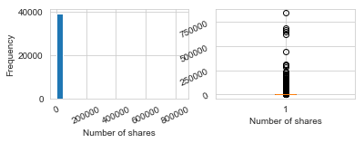

```python
# histogram of untransformed shares attribute
plt.subplot(2, 2, 1)
plt.hist(dfCopy[' shares'], bins = 20)
plt.xlabel('Number of shares')
plt.ylabel('Frequency')
plt.xticks(rotation = 25)

# boxplot of untransformed shares attribute
plt.subplot(2, 2, 2)
plt.boxplot(dfCopy[' shares'])
plt.xlabel('Number of shares')
plt.yticks(rotation = 25)
```

```
Text(0.5,0,'Log Shares')
```

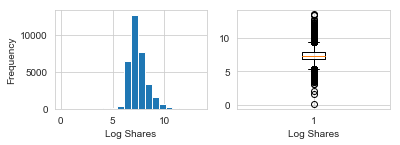

```python
# histogram of log transformed shares attribute
plt.subplot(2, 2, 1)
plt.hist(df['log_shares'], bins = 20)
plt.xlabel('Log Shares')
plt.ylabel('Frequency')

# boxplot of log transformed shares attribute
plt.subplot(2, 2, 2)
plt.boxplot(df['log_shares'])
plt.xlabel('Log Shares')
```

We already pointed out that the median number of shares is 1,400. Calculation below is to see what the corresponding median value will be for the log transformed shares attribute.

```python
df[['log_shares']].median()
```

```
log_shares    7.244299
dtype: float64
```

```python
df['popular'] = np.where(df['log_shares'] >= 7.244299, 1, 0)
dfCopy2 = df
```

We will use this median value as the cutoff between popular and unpopular articles in our classification model. This classification will be stored in a newly created attribute labeled '*popular*'.

Looking through the **`describe`** summary statistics table, we noticed multiple attributes that have similar labels and seem to represent the same measure. The [Stanford](http://cs229.stanford.edu/proj2015/328_report.pdf) study provides an organized grouping of similar attributes by the aspect of the article that it relates to. For example, the digital media aspect of the article is described by the number of images (*num_imgs*) and videos (*num_videos*) attributes.

We decided to discuss the important summary statistics of these aspects rather than go through the individual attributes one by one.

| Aspects | Features |
| --- | --- |
| Words | Number of words of the title / content, Average word length, Rate of unique / non-stop words |
| Links | Number of hyperlinks, Number of hyperlinks to other articles in Mashable |
| Digital Media | Number of images / videos |
| Publication Time | Day of the week / weekend |
| Keywords | Number of keywords, Worst/best/average keywords (#shares), Article category |
| Natural Language Processing | Closeness to five LDA topics, title / text polarity / subjectivity, rate and polarity of positive / negative words, absolute subjectivity / polarity level |
| **Target** | **Number of shares at Mashable** |

#### Words:

Looking at the statistics summary table, it didn't surprise us that the titles for these articles are kept short. The mean title word count is just over 10 words with a tight standard deviation of 2 words because publishers know that today's readers would easily lose interest before even opening the article just based off a long title.

Going through the body of the article, there are several specific measures of the rate and type of words used as listed in the screenshot above under the **words** section.

The attribute that comes to mind as the most important with regards to popularity is number of words in the article (*n_tokens_content*). The mean word count in this data set is 585 which seems short enough to hold the readers' attention for the full article and have a higher chance of sharing it. However, a 2013 study conducted by [Newswhip Analytics](https://www.newswhip.com/2013/12/article-length/) showed that articles in the 500 - 800 word count had the lowest chance of social media success which is why some news websites such as [Quartz](https://qz.com/) decided not to publish articles within that range. Considering the standard deviation of almost 484 words and max word count of 8474, there are plenty of articles that fall out of that range. Lastly, the minimum word count of 0 initially got our attention as possible outliers but upon closer inspection we found that these articles consisted only of images and videos.

After performing an extensive search, we didn't find any literature to compare with regards to rate of non-stop words (*n_non_stop_words*), rate of unique words (*n_unique_tokens*), and rate of unique non-stop words (*n_non_stop_unique_tokens*). Thus, the simple statistics for these attributes didn't seem as pertinent to review.

#### Links:¶

It would seem that including a lot of links within an article would easily distract a reader but surprisingly for this data set the mean number of links per article is just over 10. Upon closer examination, the 50% percentile corresponds to 7 links per article with the maximum coming in at an enormous 304 links so there is definitely some right skewness in the distribution.

There is an attribute measuring the number of Mashable article links (num_self_hrefs) per article. The mean number of Mashable links comes in at 3 per article which is lower than the mean of 10 total links discussed in the paragraph above. This seems reasonable since an article that only includes Mashable links might look like a self-promotion strategy for the website and lower the article's credbility.

#### Digital Media:

The mean number of images (*num_imgs*) and videos (*num_videos*) per article is ~ 4 and 1 respectively. This seems reasonable that articles would have at least a few pictures and videos to break up large text paragraphs in an effort to hold the readers' attention.

Looking at the minimum values, it is interesting to see that there are still articles with neither any images or videos included which we believe would not be considered popular on social media. On the other end of the spectrum, the max values of 128 images and 75 videos are pretty extreme and we would imagine most readers would not have the attention span to get through such an article in its entirety.

#### Summary of Simple Statistics After Log Transformations

```python
# Quick statistic summary of the transformed data set
df.describe().transpose()
```

|  | count | mean | std | min | 25% | 50% | 75% | max |
| --- | --- | --- | --- | --- | --- | --- | --- | --- |
| n_tokens_title | 33510.0 | 10.416204 | 2.134557 | 2.000000 | 9.000000 | 10.000000 | 12.000000 | 23.000000 |
| average_token_length | 33510.0 | 4.607736 | 0.646702 | 0.000000 | 4.490385 | 4.669471 | 4.852841 | 7.695652 |
| num_keywords | 33510.0 | 7.177798 | 1.952422 | 1.000000 | 6.000000 | 7.000000 | 9.000000 | 10.000000 |
| kw_max_max | 33510.0 | 753337.156073 | 213034.725810 | 0.000000 | 843300.000000 | 843300.000000 | 843300.000000 | 843300.000000 |
| kw_avg_max | 33510.0 | 241773.119564 | 122864.851517 | 0.000000 | 165789.285715 | 228286.666666 | 310000.000000 | 843300.000000 |
| kw_min_avg | 33510.0 | 1031.643292 | 1067.121534 | -1.000000 | 0.000000 | 956.466667 | 1936.365694 | 3610.124972 |
| LDA_00 | 33510.0 | 0.207364 | 0.277868 | 0.000000 | 0.025188 | 0.040000 | 0.320122 | 0.926994 |
| LDA_01 | 33510.0 | 0.141303 | 0.224786 | 0.000000 | 0.025005 | 0.033339 | 0.134308 | 0.925947 |
| LDA_02 | 33510.0 | 0.245294 | 0.295739 | 0.000000 | 0.028573 | 0.050001 | 0.432298 | 0.919999 |
| LDA_03 | 33510.0 | 0.140653 | 0.224266 | 0.000000 | 0.025033 | 0.033373 | 0.136139 | 0.925542 |
| LDA_04 | 33510.0 | 0.265356 | 0.301748 | 0.000000 | 0.029340 | 0.050763 | 0.485458 | 0.927191 |
| global_subjectivity | 33510.0 | 0.439569 | 0.099129 | 0.000000 | 0.393133 | 0.447111 | 0.497383 | 1.000000 |
| global_sentiment_polarity | 33510.0 | 0.119596 | 0.090615 | -0.377657 | 0.062231 | 0.119719 | 0.175602 | 0.727841 |
| global_rate_positive_words | 33510.0 | 0.039891 | 0.016444 | 0.000000 | 0.028889 | 0.039164 | 0.050205 | 0.155488 |
| global_rate_negative_words | 33510.0 | 0.016320 | 0.009943 | 0.000000 | 0.009768 | 0.015209 | 0.021277 | 0.139831 |
| rate_positive_words | 33510.0 | 0.695364 | 0.171064 | 0.000000 | 0.611111 | 0.714286 | 0.800000 | 1.000000 |
| rate_negative_words | 33510.0 | 0.288462 | 0.150604 | 0.000000 | 0.188679 | 0.277778 | 0.379310 | 1.000000 |
| avg_positive_polarity | 33510.0 | 0.351704 | 0.091821 | 0.000000 | 0.305024 | 0.354545 | 0.403922 | 1.000000 |
| min_positive_polarity | 33510.0 | 0.091221 | 0.064398 | 0.000000 | 0.050000 | 0.100000 | 0.100000 | 1.000000 |
| max_positive_polarity | 33510.0 | 0.762561 | 0.231811 | 0.000000 | 0.600000 | 0.800000 | 1.000000 | 1.000000 |
| avg_negative_polarity | 33510.0 | -0.255202 | 0.117386 | -1.000000 | -0.318403 | -0.250000 | -0.186667 | 0.000000 |
| min_negative_polarity | 33510.0 | -0.524040 | 0.283454 | -1.000000 | -0.700000 | -0.500000 | -0.300000 | 0.000000 |
| max_negative_polarity | 33510.0 | -0.104041 | 0.086693 | -1.000000 | -0.125000 | -0.100000 | -0.050000 | 0.000000 |
| title_subjectivity | 33510.0 | 0.265740 | 0.314245 | 0.000000 | 0.000000 | 0.100000 | 0.500000 | 1.000000 |
| title_sentiment_polarity | 33510.0 | 0.068661 | 0.252802 | -1.000000 | 0.000000 | 0.000000 | 0.136364 | 1.000000 |
| abs_title_subjectivity | 33510.0 | 0.343692 | 0.188397 | 0.000000 | 0.166667 | 0.500000 | 0.500000 | 0.500000 |
| abs_title_sentiment_polarity | 33510.0 | 0.145570 | 0.217789 | 0.000000 | 0.000000 | 0.000000 | 0.225000 | 1.000000 |
| log_n_tokens_content | 33510.0 | 5.999449 | 1.273157 | -2.302585 | 5.606170 | 6.102782 | 6.634765 | 9.044770 |
| log_n_unique_tokens | 33510.0 | -0.491878 | 0.282137 | -2.302585 | -0.566697 | -0.457923 | -0.356675 | 6.552651 |
| log_n_non_stop_words | 33510.0 | 0.057017 | 0.303731 | -2.302585 | 0.095310 | 0.095310 | 0.095310 | 6.948993 |
| log_n_non_stop_unique_tokens | 33510.0 | -0.275653 | 0.291904 | -2.302585 | -0.316947 | -0.235202 | -0.159611 | 6.477126 |
| log_num_hrefs | 33510.0 | 1.964819 | 0.986069 | -2.302585 | 1.410987 | 1.960095 | 2.572612 | 5.717357 |
| log_num_self_hrefs | 33510.0 | 0.645982 | 1.345538 | -2.302585 | 0.095310 | 1.131402 | 1.410987 | 4.754452 |
| log_num_imgs | 33510.0 | 0.366843 | 1.456365 | -2.302585 | 0.095310 | 0.095310 | 1.131402 | 4.852811 |
| log_num_videos | 33510.0 | -1.349393 | 1.432197 | -2.302585 | -2.302585 | -2.302585 | 0.095310 | 4.318821 |
| log_kw_min_min | 33510.0 | 1.155246 | 1.721834 | 0.000000 | 0.000000 | 0.000000 | 1.791759 | 5.937536 |
| log_kw_max_min | 33510.0 | 6.312276 | 1.624741 | -2.302585 | 6.096050 | 6.486313 | 6.907855 | 12.606190 |
| log_kw_avg_min | 33510.0 | 5.291667 | 1.158304 | 0.000000 | 4.963019 | 5.477788 | 5.892827 | 10.664991 |
| log_kw_min_max | 33510.0 | 3.853464 | 5.606529 | -2.302585 | -2.302585 | 7.170196 | 8.824693 | 13.645078 |
| log_kw_max_avg | 33510.0 | 8.401823 | 0.641385 | -2.302585 | 8.161793 | 8.305153 | 8.584248 | 12.606190 |
| log_kw_avg_avg | 33510.0 | 7.901533 | 0.560973 | -2.302585 | 7.746331 | 7.914672 | 8.093026 | 10.682073 |
| log_self_reference_min_shares | 33510.0 | 5.702312 | 3.891489 | -2.302585 | 6.429881 | 7.003156 | 7.783266 | 13.445027 |
| log_self_reference_max_shares | 33510.0 | 6.438064 | 4.257466 | -2.302585 | 6.907855 | 7.901044 | 8.895643 | 13.638415 |
| log_self_reference_avg_sharess | 33510.0 | 6.179735 | 4.104882 | -2.302585 | 6.863995 | 7.649740 | 8.444644 | 13.445027 |
| log_shares | 33510.0 | 7.412123 | 0.876603 | 0.095310 | 6.835292 | 7.244299 | 7.824086 | 13.445027 |
| popular | 33510.0 | 0.472307 | 0.499240 | 0.000000 | 0.000000 | 0.000000 | 1.000000 | 1.000000 |

#### Linear Regression

We can use linear regression to check which variables are nearly significant with the target variable "Log_share".

```python
df_ols = df.drop(['Channel', 'Weekday', 'popular'], axis=1) # drop categorical and added variables for OLS
```

```python
# Pioneer Linear Regression analysis with numerical variables
class_y = df_ols.log_shares
class_X = df_ols.drop(['log_shares'], axis=1) # drop target variable 'log_shares', axis = 1 - column

import statsmodels.api as sm
class_X = sm.add_constant(class_X)
ls_model_a = sm.OLS(class_y.astype(float), class_X.astype(float)).fit()
ls_model_a.summary()
```

OLS Regression Results

| Dep. Variable: | log_shares | R-squared: | 0.101 |
| --- | --- | --- | --- |
| Model: | OLS | Adj. R-squared: | 0.099 |
| Method: | Least Squares | F-statistic: | 85.00 |
| Date: | Wed, 03 Oct 2018 | Prob (F-statistic): | 0.00 |
| Time: | 18:14:24 | Log-Likelihood: | -41360. |
| No. Observations: | 33510 | AIC: | 8.281e+04 |
| Df Residuals: | 33465 | BIC: | 8.319e+04 |
| Df Model: | 44 |  |  |
| Covariance Type: | nonrobust |  |  |

|  | coef | std err | t | P>\|t\| | [0.025 | 0.975] |
| --- | --- | --- | --- | --- | --- | --- |
| const | 7.2988 | 1.665 | 4.383 | 0.000 | 4.035 | 10.563 |
| n_tokens_title | -0.0004 | 0.002 | -0.177 | 0.859 | -0.005 | 0.004 |
| average_token_length | -0.0669 | 0.021 | -3.220 | 0.001 | -0.108 | -0.026 |
| num_keywords | 0.0244 | 0.003 | 8.104 | 0.000 | 0.018 | 0.030 |
| kw_max_max | -1.765e-07 | 4.13e-08 | -4.275 | 0.000 | -2.57e-07 | -9.56e-08 |
| kw_avg_max | -2.616e-08 | 6.48e-08 | -0.404 | 0.686 | -1.53e-07 | 1.01e-07 |
| kw_min_avg | 0.0003 | 1.19e-05 | 25.954 | 0.000 | 0.000 | 0.000 |
| LDA_00 | -1.4414 | 2.079 | -0.693 | 0.488 | -5.517 | 2.634 |
| LDA_01 | -1.8100 | 2.079 | -0.871 | 0.384 | -5.885 | 2.265 |
| LDA_02 | -1.7942 | 2.080 | -0.863 | 0.388 | -5.871 | 2.282 |
| LDA_03 | -1.7301 | 2.079 | -0.832 | 0.405 | -5.805 | 2.345 |
| LDA_04 | -1.4611 | 2.079 | -0.703 | 0.482 | -5.536 | 2.614 |
| global_subjectivity | 0.4215 | 0.070 | 6.048 | 0.000 | 0.285 | 0.558 |
| global_sentiment_polarity | -0.0956 | 0.143 | -0.668 | 0.504 | -0.376 | 0.185 |
| global_rate_positive_words | 0.2555 | 0.603 | 0.423 | 0.672 | -0.927 | 1.438 |
| global_rate_negative_words | 0.8708 | 1.186 | 0.734 | 0.463 | -1.453 | 3.195 |
| rate_positive_words | 0.5442 | 0.483 | 1.128 | 0.259 | -0.402 | 1.490 |
| rate_negative_words | 0.3832 | 0.486 | 0.788 | 0.431 | -0.570 | 1.336 |
| avg_positive_polarity | -0.0585 | 0.111 | -0.525 | 0.599 | -0.277 | 0.160 |
| min_positive_polarity | -0.2368 | 0.097 | -2.451 | 0.014 | -0.426 | -0.047 |
| max_positive_polarity | -0.0281 | 0.034 | -0.820 | 0.412 | -0.095 | 0.039 |
| avg_negative_polarity | -0.0724 | 0.099 | -0.729 | 0.466 | -0.267 | 0.122 |
| min_negative_polarity | -0.0385 | 0.036 | -1.076 | 0.282 | -0.109 | 0.032 |
| max_negative_polarity | 0.0497 | 0.087 | 0.573 | 0.567 | -0.120 | 0.220 |
| title_subjectivity | 0.0482 | 0.022 | 2.169 | 0.030 | 0.005 | 0.092 |
| title_sentiment_polarity | 0.0671 | 0.021 | 3.209 | 0.001 | 0.026 | 0.108 |
| abs_title_subjectivity | 0.1272 | 0.029 | 4.315 | 0.000 | 0.069 | 0.185 |
| abs_title_sentiment_polarity | 0.0503 | 0.032 | 1.558 | 0.119 | -0.013 | 0.114 |
| log_n_tokens_content | -0.0943 | 0.022 | -4.346 | 0.000 | -0.137 | -0.052 |
| log_n_unique_tokens | -0.6368 | 0.141 | -4.502 | 0.000 | -0.914 | -0.360 |
| log_n_non_stop_words | 0.1798 | 0.228 | 0.789 | 0.430 | -0.267 | 0.627 |
| log_n_non_stop_unique_tokens | 0.2569 | 0.113 | 2.282 | 0.022 | 0.036 | 0.477 |
| log_num_hrefs | 0.0817 | 0.007 | 11.102 | 0.000 | 0.067 | 0.096 |
| log_num_self_hrefs | -0.0332 | 0.006 | -5.153 | 0.000 | -0.046 | -0.021 |
| log_num_imgs | 0.0166 | 0.004 | 4.090 | 0.000 | 0.009 | 0.025 |
| log_num_videos | 0.0411 | 0.004 | 11.374 | 0.000 | 0.034 | 0.048 |
| log_kw_min_min | -0.0075 | 0.005 | -1.437 | 0.151 | -0.018 | 0.003 |
| log_kw_max_min | -0.0601 | 0.010 | -5.788 | 0.000 | -0.080 | -0.040 |
| log_kw_avg_min | 0.1060 | 0.015 | 6.846 | 0.000 | 0.076 | 0.136 |
| log_kw_min_max | -0.0514 | 0.002 | -23.299 | 0.000 | -0.056 | -0.047 |
| log_kw_max_avg | 0.0228 | 0.022 | 1.024 | 0.306 | -0.021 | 0.066 |
| log_kw_avg_avg | 0.1115 | 0.027 | 4.192 | 0.000 | 0.059 | 0.164 |
| log_self_reference_min_shares | -0.0559 | 0.011 | -5.243 | 0.000 | -0.077 | -0.035 |
| log_self_reference_max_shares | -0.1583 | 0.024 | -6.549 | 0.000 | -0.206 | -0.111 |
| log_self_reference_avg_sharess | 0.2407 | 0.033 | 7.318 | 0.000 | 0.176 | 0.305 |

| Omnibus: | 6140.349 | Durbin-Watson: | 1.906 |
| --- | --- | --- | --- |
| Prob(Omnibus): | 0.000 | Jarque-Bera (JB): | 17302.005 |
| Skew: | 0.978 | Prob(JB): | 0.00 |
| Kurtosis: | 5.927 | Cond. No. | 9.01e+08 |

Warnings:  
[1] Standard Errors assume that the covariance matrix of the errors is correctly specified.  
[2] The condition number is large, 9.01e+08. This might indicate that there are  
strong multicollinearity or other numerical problems.

##### Findings from intial linear regression analysis

From the initial anlaysis there does not appear to be many variable that will be useful in trying to predict the number of share, and we see a warning about strong multicollinearity. In the presence of multicollinearity, regression estimates are unstable and have high standard errors.

#### Eliminate multicollinearity by keeping variables with variance inflation factor (VIF) <= 4

For the multicollinearity problem which affects our regression model, we use VIF criterion (VIF <=4) to eliminate interfering variables.

VIF criterion evaluates the relationship of the response varaible "log_shares" with all other explanatory variables. Its value is a measure of how much the variance of the coefficient derived from the model is inflated by collinearity.

The pairwise correaltion (see Section6) can be checked either in graph or to view in correlation matrix. Generally, VIF value <= 4 suggests no multicollinearity, whereas a value of >= 10 implies serious multicollinearity.

```python
# Eliminate multicollinearity by keeping variables with variance inflation factor (VIF) <= 4

from statsmodels.stats.outliers_influence import variance_inflation_factor

independent_variable = ['n_tokens_title','average_token_length','num_keywords','kw_max_max','kw_avg_max','kw_min_avg','LDA_00',
      'LDA_01','LDA_02','LDA_03','LDA_04','global_subjectivity','global_sentiment_polarity',
      'global_rate_positive_words','global_rate_negative_words','rate_positive_words','rate_negative_words',
      'avg_positive_polarity','min_positive_polarity','max_positive_polarity','avg_negative_polarity',
      'min_negative_polarity','max_negative_polarity','title_subjectivity','title_sentiment_polarity',
      'abs_title_subjectivity','abs_title_sentiment_polarity','log_n_tokens_content','log_n_unique_tokens',
      'log_n_non_stop_words','log_n_non_stop_unique_tokens','log_num_hrefs','log_num_self_hrefs','log_num_imgs',
      'log_num_videos','log_kw_min_min','log_kw_max_min','log_kw_avg_min','log_kw_min_max','log_kw_max_avg',
      'log_kw_avg_avg','log_self_reference_min_shares', 'log_self_reference_max_shares',
      'log_self_reference_avg_sharess']

vX = df[independent_variable]
vy = df['log_shares']
thresh = 4 # set the VIF criterion (VIF <=4)

for i in np.arange(0, len(independent_variable)):
    vif = [variance_inflation_factor(vX[independent_variable].values, ix)
    for ix in range(vX[independent_variable].shape[1])]
    maxloc = vif.index(max(vif))
    if max(vif) > thresh:
        del independent_variable[maxloc]
    else:
        break
print('Final variables:', independent_variable)
```

[output not shown]

#### Linear Regession with 17 independent variables with VIF < 4 for multicollinearity elimination

These 17 variables are: ['LDA_00', 'LDA_01', 'LDA_02', 'LDA_03', 'LDA_04', 'global_sentiment_polarity', 'min_positive_polarity', 'max_negative_polarity', 'title_subjectivity', 'title_sentiment_polarity', 'abs_title_sentiment_polarity', 'log_n_non_stop_words', 'log_num_self_hrefs', 'log_num_imgs', 'log_num_videos', 'log_kw_min_min', 'log_kw_min_max']

```python
# Use the selected 17 independent variables with VIF < 4 and recheck OLS

df_ols_vif = df[['LDA_00', 'LDA_01', 'LDA_02', 'LDA_03', 'LDA_04', 'global_sentiment_polarity',
                 'min_positive_polarity', 'max_negative_polarity', 'title_subjectivity',
                 'title_sentiment_polarity', 'abs_title_sentiment_polarity', 'log_n_non_stop_words',
                 'log_num_self_hrefs', 'log_num_imgs', 'log_num_videos', 'log_kw_min_min',
                 'log_kw_min_max', 'log_shares']]

vif_y = df_ols_vif.log_shares
vif_X = df_ols_vif.drop(['log_shares'], axis=1) # axis = 1 - column

import statsmodels.api as sm
vif_X = sm.add_constant(vif_X)
vif_ols_model = sm.OLS(vif_y.astype(float), vif_X.astype(float)).fit()
vif_ols_model.summary()
```

OLS Regression Results

| Dep. Variable: | log_shares | R-squared: | 0.046 |
| --- | --- | --- | --- |
| Model: | OLS | Adj. R-squared: | 0.046 |
| Method: | Least Squares | F-statistic: | 95.18 |
| Date: | Wed, 03 Oct 2018 | Prob (F-statistic): | 0.00 |
| Time: | 18:16:50 | Log-Likelihood: | -42344. |
| No. Observations: | 33510 | AIC: | 8.472e+04 |
| Df Residuals: | 33492 | BIC: | 8.488e+04 |
| Df Model: | 17 |  |  |
| Covariance Type: | nonrobust |  |  |

|  | coef | std err | t | P>\|t\| | [0.025 | 0.975] |
| --- | --- | --- | --- | --- | --- | --- |
| const | 9.3776 | 0.864 | 10.850 | 0.000 | 7.684 | 11.072 |
| LDA_00 | -1.7353 | 0.865 | -2.007 | 0.045 | -3.430 | -0.041 |
| LDA_01 | -2.1601 | 0.865 | -2.498 | 0.013 | -3.855 | -0.465 |
| LDA_02 | -2.2424 | 0.865 | -2.593 | 0.010 | -3.937 | -0.548 |
| LDA_03 | -1.9596 | 0.865 | -2.265 | 0.024 | -3.655 | -0.264 |
| LDA_04 | -1.7136 | 0.865 | -1.982 | 0.048 | -3.409 | -0.019 |
| global_sentiment_polarity | 0.1733 | 0.056 | 3.068 | 0.002 | 0.063 | 0.284 |
| min_positive_polarity | -0.4376 | 0.076 | -5.759 | 0.000 | -0.586 | -0.289 |
| max_negative_polarity | -0.0676 | 0.056 | -1.213 | 0.225 | -0.177 | 0.042 |
| title_subjectivity | 0.0350 | 0.021 | 1.652 | 0.099 | -0.007 | 0.077 |
| title_sentiment_polarity | 0.0502 | 0.021 | 2.368 | 0.018 | 0.009 | 0.092 |
| abs_title_sentiment_polarity | 0.0754 | 0.033 | 2.296 | 0.022 | 0.011 | 0.140 |
| log_n_non_stop_words | -0.1109 | 0.017 | -6.523 | 0.000 | -0.144 | -0.078 |
| log_num_self_hrefs | 0.0170 | 0.004 | 4.454 | 0.000 | 0.010 | 0.024 |
| log_num_imgs | 0.0350 | 0.003 | 10.088 | 0.000 | 0.028 | 0.042 |
| log_num_videos | 0.0516 | 0.004 | 14.327 | 0.000 | 0.045 | 0.059 |
| log_kw_min_min | 0.0118 | 0.003 | 4.147 | 0.000 | 0.006 | 0.017 |
| log_kw_min_max | 0.0018 | 0.001 | 2.072 | 0.038 | 9.53e-05 | 0.003 |

| Omnibus: | 6182.039 | Durbin-Watson: | 1.878 |
| --- | --- | --- | --- |
| Prob(Omnibus): | 0.000 | Jarque-Bera (JB): | 16672.199 |
| Skew: | 0.998 | Prob(JB): | 0.00 |
| Kurtosis: | 5.820 | Cond. No. | 3.13e+03 |

Warnings:  
[1] Standard Errors assume that the covariance matrix of the errors is correctly specified.  
[2] The condition number is large, 3.13e+03. This might indicate that there are  
strong multicollinearity or other numerical problems.

#### Check correlation matrix table to confirm there are no multicolinearity variables in the dataset

From the linear regression analysis with 17 selected independent variables, there are still warnings related to conditional number, indicating there are potential other numberical problems. For confirmation, we check the correlation matrix table that there are no multicolinearity varibles in the dataset.

```python
# Check with correlation matrix table to confirm there are no multicoliearity variables in the dataset
df_corr_vif = df_ols_vif.corr()
df_corr_vif
```

|  | LDA_00 | LDA_01 | LDA_02 | LDA_03 | LDA_04 | global_sentiment_polarity | min_positive_polarity | max_negative_polarity | title_subjectivity | title_sentiment_polarity | abs_title_sentiment_polarity | log_n_non_stop_words | log_num_self_hrefs | log_num_imgs | log_num_videos | log_kw_min_min | log_kw_min_max | log_shares |
| --- | --- | --- | --- | --- | --- | --- | --- | --- | --- | --- | --- | --- | --- | --- | --- | --- | --- | --- |
| LDA_00 | 1.000000 | -0.190662 | -0.324424 | -0.196147 | -0.315011 | 0.127972 | -0.090303 | -0.032507 | -0.028283 | 0.038120 | -0.007039 | 0.053862 | -0.046353 | -0.085564 | -0.127631 | 0.063423 | 0.025697 | 0.073355 |
| LDA_01 | -0.190662 | 1.000000 | -0.249520 | -0.075496 | -0.268650 | -0.038950 | 0.028717 | -0.037295 | 0.061746 | -0.018242 | 0.042687 | 0.015135 | 0.038437 | 0.028366 | 0.103911 | -0.001195 | -0.011869 | -0.053342 |
| LDA_02 | -0.324424 | -0.249520 | 1.000000 | -0.241686 | -0.315749 | -0.265554 | -0.031314 | 0.072557 | -0.053668 | -0.081502 | -0.064282 | -0.049820 | -0.151462 | -0.005647 | -0.057728 | -0.121838 | -0.005464 | -0.149864 |
| LDA_03 | -0.196147 | -0.075496 | -0.241686 | 1.000000 | -0.269422 | 0.010242 | 0.030377 | -0.040889 | 0.080214 | 0.030390 | 0.079210 | -0.104066 | 0.055929 | 0.028950 | 0.301906 | -0.047724 | 0.053897 | 0.024631 |
| LDA_04 | -0.315011 | -0.268650 | -0.315749 | -0.269422 | 1.000000 | 0.163956 | 0.070019 | 0.016876 | -0.026886 | 0.035805 | -0.021120 | 0.063054 | 0.120806 | 0.041437 | -0.127617 | 0.097435 | -0.049633 | 0.100618 |
| global_sentiment_polarity | 0.127972 | -0.038950 | -0.265554 | 0.010242 | 0.163956 | 1.000000 | 0.053840 | -0.030722 | 0.029459 | 0.241570 | 0.082020 | 0.166405 | 0.086608 | 0.022048 | -0.027949 | 0.122369 | -0.018809 | 0.069445 |
| min_positive_polarity | -0.090303 | 0.028717 | -0.031314 | 0.030377 | 0.070019 | 0.053840 | 1.000000 | -0.146210 | -0.007815 | -0.007135 | -0.006090 | 0.178594 | 0.013231 | -0.144824 | 0.015300 | 0.017153 | -0.000528 | -0.042852 |
| max_negative_polarity | -0.032507 | -0.037295 | 0.072557 | -0.040889 | 0.016876 | -0.030722 | -0.146210 | 1.000000 | -0.002323 | 0.002749 | -0.001327 | -0.151311 | -0.040099 | 0.128289 | -0.007256 | -0.039003 | -0.002689 | 0.002329 |
| title_subjectivity | -0.028283 | 0.061746 | -0.053668 | 0.080214 | -0.026886 | 0.029459 | -0.007815 | -0.002323 | 1.000000 | 0.243901 | 0.707422 | -0.015614 | -0.003674 | 0.018573 | 0.067894 | -0.020032 | 0.014572 | 0.034740 |
| title_sentiment_polarity | 0.038120 | -0.018242 | -0.081502 | 0.030390 | 0.035805 | 0.241570 | -0.007135 | 0.002749 | 0.243901 | 1.000000 | 0.429881 | -0.010731 | 0.014600 | 0.053392 | 0.010378 | 0.044634 | 0.016198 | 0.050559 |
| abs_title_sentiment_polarity | -0.007039 | 0.042687 | -0.064282 | 0.079210 | -0.021120 | 0.082020 | -0.006090 | -0.001327 | 0.707422 | 0.429881 | 1.000000 | -0.025926 | -0.006329 | 0.036389 | 0.055008 | -0.003289 | 0.027089 | 0.044928 |
| log_n_non_stop_words | 0.053862 | 0.015135 | -0.049820 | -0.104066 | 0.063054 | 0.166405 | 0.178594 | -0.151311 | -0.015614 | -0.010731 | -0.025926 | 1.000000 | 0.278599 | 0.040953 | -0.027436 | 0.056343 | -0.008579 | -0.017820 |
| log_num_self_hrefs | -0.046353 | 0.038437 | -0.151462 | 0.055929 | 0.120806 | 0.086608 | 0.013231 | -0.040099 | -0.003674 | 0.014600 | -0.006329 | 0.278599 | 1.000000 | 0.186165 | 0.109000 | -0.056041 | 0.114512 | 0.056306 |
| log_num_imgs | -0.085564 | 0.028366 | -0.005647 | 0.028950 | 0.041437 | 0.022048 | -0.144824 | 0.128289 | 0.018573 | 0.053392 | 0.036389 | 0.040953 | 0.186165 | 1.000000 | -0.161498 | -0.127216 | 0.044671 | 0.047926 |
| log_num_videos | -0.127631 | 0.103911 | -0.057728 | 0.301906 | -0.127617 | -0.027949 | 0.015300 | -0.007256 | 0.067894 | 0.010378 | 0.055008 | -0.027436 | 0.109000 | -0.161498 | 1.000000 | -0.126694 | 0.044067 | 0.057658 |
| log_kw_min_min | 0.063423 | -0.001195 | -0.121838 | -0.047724 | 0.097435 | 0.122369 | 0.017153 | -0.039003 | -0.020032 | 0.044634 | -0.003289 | 0.056343 | -0.056041 | -0.127216 | -0.126694 | 1.000000 | -0.173400 | 0.026224 |
| log_kw_min_max | 0.025697 | -0.011869 | -0.005464 | 0.053897 | -0.049633 | -0.018809 | -0.000528 | -0.002689 | 0.014572 | 0.016198 | 0.027089 | -0.008579 | 0.114512 | 0.044671 | 0.044067 | -0.173400 | 1.000000 | 0.016375 |
| log_shares | 0.073355 | -0.053342 | -0.149864 | 0.024631 | 0.100618 | 0.069445 | -0.042852 | 0.002329 | 0.034740 | 0.050559 | 0.044928 | -0.017820 | 0.056306 | 0.047926 | 0.057658 | 0.026224 | 0.016375 | 1.000000 |

##### Linear Regression with 12 independent variables of project interest

Considering that we have eliminated the strong multicollinearity variables and there are still numerical problems, we think it might be caused by high p-value (>0.05), and min/max varaibles and finally select 12 independent variables of project interest.

```python
## Recheck linear regression analysis with 12 selected variables.

df_ols_endSelection = df[['LDA_01', 'LDA_02', 'LDA_03', 'global_sentiment_polarity',
                          'min_positive_polarity','title_sentiment_polarity', 'abs_title_sentiment_polarity',
                          'log_n_non_stop_words', 'log_num_self_hrefs', 'log_num_imgs', 'log_num_videos',
                          'log_kw_min_min', 'log_shares']]

endSelection_y = df_ols_endSelection.log_shares
endSelection_X = df_ols_endSelection.drop(['log_shares'], axis=1) # axis = 1 -  column

import statsmodels.api as sm
endSelection_X = sm.add_constant(endSelection_X)
endSelection_ols_model = sm.OLS(endSelection_y.astype(float), endSelection_X.astype(float)).fit()
endSelection_ols_model.summary()
```

OLS Regression Results

| Dep. Variable: | log_shares | R-squared: | 0.046 |
| --- | --- | --- | --- |
| Model: | OLS | Adj. R-squared: | 0.045 |
| Method: | Least Squares | F-statistic: | 133.7 |
| Date: | Wed, 03 Oct 2018 | Prob (F-statistic): | 0.00 |
| Time: | 18:16:50 | Log-Likelihood: | -42351. |
| No. Observations: | 33510 | AIC: | 8.473e+04 |
| Df Residuals: | 33497 | BIC: | 8.484e+04 |
| Df Model: | 12 |  |  |
| Covariance Type: | nonrobust |  |  |

|  | coef | std err | t | P>\|t\| | [0.025 | 0.975] |
| --- | --- | --- | --- | --- | --- | --- |
| const | 7.6718 | 0.016 | 484.585 | 0.000 | 7.641 | 7.703 |
| LDA_01 | -0.4364 | 0.022 | -19.654 | 0.000 | -0.480 | -0.393 |
| LDA_02 | -0.5201 | 0.018 | -28.825 | 0.000 | -0.555 | -0.485 |
| LDA_03 | -0.2330 | 0.023 | -10.006 | 0.000 | -0.279 | -0.187 |
| global_sentiment_polarity | 0.1670 | 0.056 | 2.960 | 0.003 | 0.056 | 0.278 |
| min_positive_polarity | -0.4235 | 0.075 | -5.647 | 0.000 | -0.570 | -0.276 |
| title_sentiment_polarity | 0.0479 | 0.021 | 2.268 | 0.023 | 0.007 | 0.089 |
| abs_title_sentiment_polarity | 0.1133 | 0.024 | 4.734 | 0.000 | 0.066 | 0.160 |
| log_n_non_stop_words | -0.1053 | 0.017 | -6.311 | 0.000 | -0.138 | -0.073 |
| log_num_self_hrefs | 0.0180 | 0.004 | 4.774 | 0.000 | 0.011 | 0.025 |
| log_num_imgs | 0.0349 | 0.003 | 10.162 | 0.000 | 0.028 | 0.042 |
| log_num_videos | 0.0517 | 0.004 | 14.379 | 0.000 | 0.045 | 0.059 |
| log_kw_min_min | 0.0109 | 0.003 | 3.874 | 0.000 | 0.005 | 0.016 |

| Omnibus: | 6172.664 | Durbin-Watson: | 1.878 |
| --- | --- | --- | --- |
| Prob(Omnibus): | 0.000 | Jarque-Bera (JB): | 16625.635 |
| Skew: | 0.997 | Prob(JB): | 0.00 |
| Kurtosis: | 5.816 | Cond. No. | 42.7 |

Warnings:  
[1] Standard Errors assume that the covariance matrix of the errors is correctly specified.

##### Recheck variable correlation with the final 12 selected varaibles for confirmation

```python
## Recheck variable correlation with 8 selected variables.
df_ols_endSelection.corr()
```

|  | LDA_01 | LDA_02 | LDA_03 | global_sentiment_polarity | min_positive_polarity | title_sentiment_polarity | abs_title_sentiment_polarity | log_n_non_stop_words | log_num_self_hrefs | log_num_imgs | log_num_videos | log_kw_min_min | log_shares |
| --- | --- | --- | --- | --- | --- | --- | --- | --- | --- | --- | --- | --- | --- |
| LDA_01 | 1.000000 | -0.249520 | -0.075496 | -0.038950 | 0.028717 | -0.018242 | 0.042687 | 0.015135 | 0.038437 | 0.028366 | 0.103911 | -0.001195 | -0.053342 |
| LDA_02 | -0.249520 | 1.000000 | -0.241686 | -0.265554 | -0.031314 | -0.081502 | -0.064282 | -0.049820 | -0.151462 | -0.005647 | -0.057728 | -0.121838 | -0.149864 |
| LDA_03 | -0.075496 | -0.241686 | 1.000000 | 0.010242 | 0.030377 | 0.030390 | 0.079210 | -0.104066 | 0.055929 | 0.028950 | 0.301906 | -0.047724 | 0.024631 |
| global_sentiment_polarity | -0.038950 | -0.265554 | 0.010242 | 1.000000 | 0.053840 | 0.241570 | 0.082020 | 0.166405 | 0.086608 | 0.022048 | -0.027949 | 0.122369 | 0.069445 |
| min_positive_polarity | 0.028717 | -0.031314 | 0.030377 | 0.053840 | 1.000000 | -0.007135 | -0.006090 | 0.178594 | 0.013231 | -0.144824 | 0.015300 | 0.017153 | -0.042852 |
| title_sentiment_polarity | -0.018242 | -0.081502 | 0.030390 | 0.241570 | -0.007135 | 1.000000 | 0.429881 | -0.010731 | 0.014600 | 0.053392 | 0.010378 | 0.044634 | 0.050559 |
| abs_title_sentiment_polarity | 0.042687 | -0.064282 | 0.079210 | 0.082020 | -0.006090 | 0.429881 | 1.000000 | -0.025926 | -0.006329 | 0.036389 | 0.055008 | -0.003289 | 0.044928 |
| log_n_non_stop_words | 0.015135 | -0.049820 | -0.104066 | 0.166405 | 0.178594 | -0.010731 | -0.025926 | 1.000000 | 0.278599 | 0.040953 | -0.027436 | 0.056343 | -0.017820 |
| log_num_self_hrefs | 0.038437 | -0.151462 | 0.055929 | 0.086608 | 0.013231 | 0.014600 | -0.006329 | 0.278599 | 1.000000 | 0.186165 | 0.109000 | -0.056041 | 0.056306 |
| log_num_imgs | 0.028366 | -0.005647 | 0.028950 | 0.022048 | -0.144824 | 0.053392 | 0.036389 | 0.040953 | 0.186165 | 1.000000 | -0.161498 | -0.127216 | 0.047926 |
| log_num_videos | 0.103911 | -0.057728 | 0.301906 | -0.027949 | 0.015300 | 0.010378 | 0.055008 | -0.027436 | 0.109000 | -0.161498 | 1.000000 | -0.126694 | 0.057658 |
| log_kw_min_min | -0.001195 | -0.121838 | -0.047724 | 0.122369 | 0.017153 | 0.044634 | -0.003289 | 0.056343 | -0.056041 | -0.127216 | -0.126694 | 1.000000 | 0.026224 |
| log_shares | -0.053342 | -0.149864 | 0.024631 | 0.069445 | -0.042852 | 0.050559 | 0.044928 | -0.017820 | 0.056306 | 0.047926 | 0.057658 | 0.026224 | 1.000000 |

##### Linear Regrssion Results with the 12 Identified Variables

From the results of linear regression and correlation checks, we can see the issue of multicollinearity and other numerical problems have been resolved and the all the variables in the model are signifcant (p-values < .05).

##### Check for Normal Distribution & Skewness of the 12 variables

```
array([[<matplotlib.axes._subplots.AxesSubplot object at 0x000002315F216A90>,
      dtype=object)
```

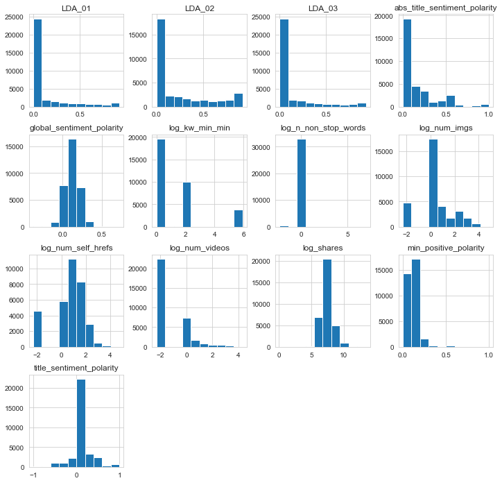

```python
# Histogram for most interesting attributes

df_ols_endSelection.hist(figsize=(12,12))
```

Back to Resubmission Corrections

### 05. Visualize Attributes

Back to top

#### Section Objective:

Visualize the most interesting attributes (at least 5 attributes, your opinion on what is interesting). Important: Interpret the implications for each visualization. Explain for each attribute why the chosen visualization is appropriate.

For this section, rather than going through and visualizing the attributes according to their corresponding aspect as we did in the **Simple Statistics** section, we decided to focus on the attributes that had obvious trends.

#### Day of the week:

The *Weekday* attribute was the most obvious trend that we noticed right away. The barplot below demonstrates that the number of articles published during the week is greater than the weekend. Drawing an anecdotal parallel to the typical workweek, this pattern seems to represent the productivity of white collar office workers where Monday starts off slower and picks up mid-week and eventually drops off by the weekend which might also be the case for publishers sucha as Mashable. This barplot doesn't give us an insight into the effect that publishing on a certain weekday has on the popularity of an article.

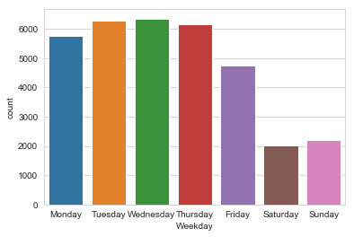

```python
# Create countplot for each weekday
sns.countplot('Weekday', data = df)
```

The side by side plot below breaks out whether the article is popular (True - yellow bar) or not (False - blue bar) and assigns it to the corresponding weekday during which it was published.

The interesting trend that we noticed here is that the proportion of popular articles tends to be higher during the weekend than during the week. A possible explanation for this could be that a typical reader has more leisure time during the weekend to get through several articles and is more likely to share them on social media.

This difference in the ratio of popular to unpopular articles is important to understand as it could influence the predictive accuracy of a classification model.

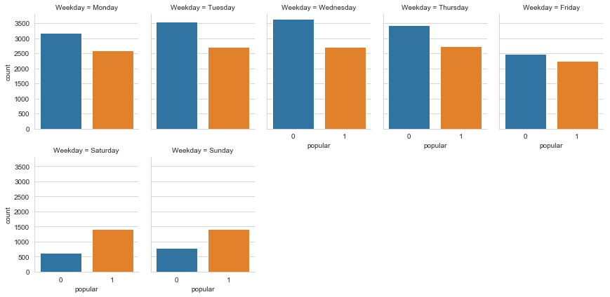

```python
# Categorical plot splitting out the popular versus unpopular articles by weekday
sns.catplot('popular', col="Weekday", col_wrap = 5, data=df, kind="count", height=3, aspect=.8)
```

#### Data Channel:

The *Channel* attribute is another one that we immediately noticed a strong relationship. The horizontal barchart below shows a direct comparison in the number of articles published for each data channel. We can see that the *lifestyle* category has the lowest number of articles published for this data set while the *World* category has the highest number.

Again, this chart only provides part of the picture. It would seem that publishers such as Mashable are catering to their readers with respect to the type of content they provide. For this reason we need to take a closer look at what proportion of articles are considered popular within each channel.

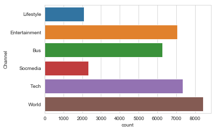

```python
# Create countplot for each data channel
sns.countplot(y = 'Channel', data = df)
```

The plot below highlights some interesting differences in the ratio of popular articles for each of data channels. Even though the *World* channel has the most articles published in this data set, it also has the largest number of unpopular articles which is closely followed by the *Entertainment* channel. On the other hand, the *Tech*, *Socmedia*, and *Lifestyle* channels have higher proportions of popular articles. This might be a result of the readers having a greater personal interest, such as a hobby, in these channels making them more likely to share the article on social media.

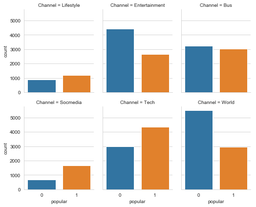

```python
# Categorical plot splitting out the popular versus unpopular articles by data channel
sns.catplot('popular', col="Channel", col_wrap = 3, data=df, kind="count", height=3, aspect=.8)
```

#### Digital Media:

We all often hear the phrase "a picture says a thousand words" so it would be interesting to see whether that holds true for this data set. Since we already examined the distribution for the number of images (*num_imgs*) and videos (*num_videos*) per article in the **Summary Statistics** section, we wanted to tie in the *channel* attribute discussed above.

The first violin plot below shows the log transformed number of images categorized by the data channel and with the distribution color coded by whether the article is popular or not. It seems that most of the channels are trimodal with the exception of the business channel. Comparing the distributions of the popular versus unpopular articles, there doesn't seem to be any obvious deviations which suggests that this attribute might not have a strong influence on the popularity.

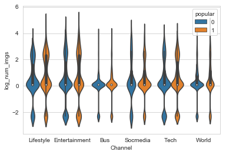

```python
# Violin plot of popular versus unpopular articles measured by log_num_images categorized by data channel
sns.violinplot(x = "Channel", y = "log_num_imgs", hue = "popular", data = df)
```

The same violin plot was created for the log transformed numer of videos. The main difference here when comparing to the images plot above is that most of the channels have a weak bimodal distribution. The entertainment channel two strong peaks throughout it's distribution suggesting these articles typically have more videos included in comparison to other channels. Again, there is no obvious differentiation between the popular and unpopular articles.

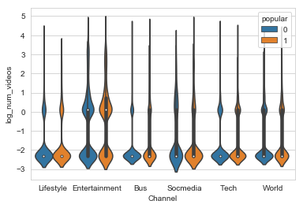

```python
# Violin plot of popular versus unpopular articles measured by log_num_videos categorized by data channel
sns.violinplot(x = "Channel", y = "log_num_videos", hue = "popular", data = df)
```

#### Natural Language Processing Attributes:

The natural language processing attributes in this data set require some research to gain an understanding into what they represent. Prior to performing a lot of research into these attributes, we find some obvious trends that could possibly be explained without the domian knowledge.

The kernel density estimation plot below shows that the rate of positive words (left-hand side) is almost a mirror image of the rate of negative words (right-hand side) of an article. It would seem that including both of these attributes in a classification model could potentially lower the accuracy. It would be interesting to test this is theory when we build our model.

```
Text(0.5,0,'Rate of negative words')
```

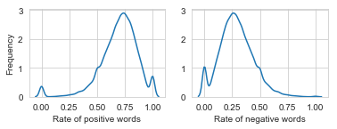

```python
# kde plot for rate of positive words
plt.subplot(2, 2, 1)
sns.kdeplot(np.array(df['rate_positive_words']))
plt.xlabel('Rate of positive words')
plt.ylabel('Frequency')

# kde plot for rate of negative words
plt.subplot(2, 2, 2)
sns.kdeplot(np.array(df['rate_negative_words']))
plt.xlabel('Rate of negative words')
```

#### Number of Words:

We wanted to understand if the number of words in an article, be it the title or the body, has an obvious relationship with how popular it is.

First, we looked at the distribution of the number of words in the title (*n_tokens_title*). The plot below displays a normal distribution with the peak frequency right around the 10 word count mark.

```
(0, 20)
```

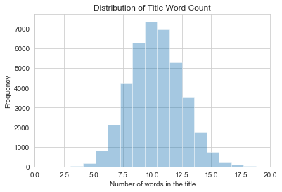

```python
# distribution plot of title word count
ax = sns.distplot(dfCopy[' n_tokens_title'], bins = 20, kde = False)
plt.xlabel('Number of words in the title')
plt.ylabel('Frequency')
plt.title('Distribution of Title Word Count')
ax.set_xlim(0, 20)
```

As we discussed in the **Summary Statistics** section, the number of words in the body of the article (*n_tokens_content*) has a heavily right skewed distribution. It seems that the majority of the pulbished articles tend to stay within the 2,000 word count limit but surprsingly, there are plenty of articles that push that limit. By applying a log transformation to this attribute, we were able to improve this to a normal distribution with a small left tail. The diagram below shows the difference in the untransformed versus (left-hand side) the log transformed distribution (right-hand side).

By looking through these distributions, we are able to make a better judgement on which variables we will include in our classification model.

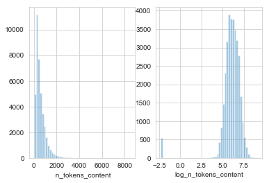

```python
# side by side distribution plots of untransformed and log transformed article word count
fig, ax = plt.subplots(1,2)
sns.distplot(dfCopy[' n_tokens_content'], kde = False, ax = ax[0])
sns.distplot(df['log_n_tokens_content'], kde = False, ax = ax[1])
fig.show()
```

### 06. Explore Joint Attributes

Back to top

#### Section Objective:

Visualize relationships between attributes: Look at the attributes via scatter plots, correlation, cross-tabulation, group-wise averages, etc. as appropriate. Explain any interesting relationships.*

##### In this section, we have accomplished:

06_01 Correlation heatmap to visualize relationships between attributes

06_02 Subset of highly correlated attributes

06_03 Larger subset of highly correlated attributes

06_04 Pairplot for LDA cluster (LDA_01, LDA_02, LDA-03), as grouped by Weekday and Channel

06_05 Pairplot for Polarity cluster as grouped by Weekday and Channel

06_07 Pairplot for variables num_imgs and num_videos, as grouped by Weekday and Channel

#### 06_01 Correlation heatmap to visualize relationships between attributes

Considering we are dealing with a large number of attirbutes in this dataset, we decided that a correlation heatmap would be a good way to visualize the correlations that might exist between them. Just to make it clear, the heatmap below displays negative correlations in a light yellow color and positive correlations in dark blue and the scale for the correlation coefficients ranges from -1 to 1.

This served as a starting point for us to pick out attributes that had strong relationships and would be worth taking a deeper look for what this relationship represents. As an example, when looking at the *average_token_length* attribute, we can see that it is positively correlated to the attributes *log_num_hrefs*, *log_n_non_stop_unique_tokens*, *log_n_non_stop_words*, *log_n_tokens_contents* amongst many others.

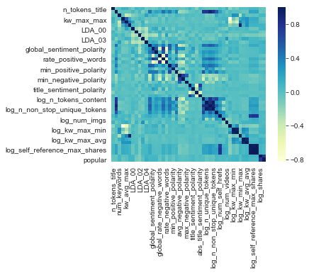

```python
# Correaltion heatmap with target varaible 'log_shares' and other independent varaibles

sns.heatmap(df.corr(), vmax=1, square=True, cmap="YlGnBu")
plt.rcParams["figure.figsize"] = [14,14]
plt.show()
```

#### Listing the most important attributes in relation to the *log_shares* attribute

From the list below, we were able to identify our top 20 continuous attributes of interest as follows:

*log_kw_avg_avg* (0.1297), *log_kw_max_avg* (0.1218), *LDA_04* (0.1006), *kw_min_avg* (0.0901), *log_kw_avg_min* (0.0898), *log_self_reference_avg_sharess* (0.0882), *log_self_reference_max_shares* (0.0871), *log_self_reference_min_shares* (0.0831), *log_kw_max_min* (0.0826), *LDA_00* (0.0734), *num_keywords* (0.0724), *global_rate_positive_words* (0.0721), *global_subjectivity* (0.0721), *global_sentiment_polarity* (0.0694), *log_num_hrefs* (0.0643), *log_num_videos* (0.0577), *log_num_self_hrefs* (0.0563), *title_sentiment_polarity* (0.0506), *rate_positive_words* (0.0481), *log_num_imgs* (0.0479)

Legend : *attribute* (correlation coefficient)

```python
# Correaltion ranking table with target varaible 'log_shares' and other independent varaibles

df_corr = df.corr()
df_corr['log_shares'].sort_values(ascending=False) # sort the variable with 'log_shares'
```

```
log_shares                        1.000000
popular                           0.744088
log_kw_avg_avg                    0.129738
log_kw_max_avg                    0.121767
LDA_04                            0.100618
kw_min_avg                        0.090065
log_kw_avg_min                    0.089764
log_self_reference_avg_sharess    0.088241
log_self_reference_max_shares     0.087063
log_self_reference_min_shares     0.083102
log_kw_max_min                    0.082610
LDA_00                            0.073355
num_keywords                      0.072374
global_rate_positive_words        0.072117
global_subjectivity               0.072063
global_sentiment_polarity         0.069445
log_num_hrefs                     0.064288
log_num_videos                    0.057658
log_num_self_hrefs                0.056306
title_sentiment_polarity          0.050559
rate_positive_words               0.048052
log_num_imgs                      0.047926
max_positive_polarity             0.046439
abs_title_sentiment_polarity      0.044928
title_subjectivity                0.034740
log_kw_min_min                    0.026224
LDA_03                            0.024631
avg_positive_polarity             0.024334
log_kw_min_max                    0.016375
log_n_tokens_content              0.010384
kw_avg_max                        0.004841
max_negative_polarity             0.002329
abs_title_subjectivity            0.001974
kw_max_max                       -0.015043
avg_negative_polarity            -0.015867
log_n_non_stop_words             -0.017820
min_negative_polarity            -0.020890
global_rate_negative_words       -0.021690
n_tokens_title                   -0.027822
log_n_non_stop_unique_tokens     -0.041660
min_positive_polarity            -0.042852
average_token_length             -0.048687
log_n_unique_tokens              -0.049625
LDA_01                           -0.053342
rate_negative_words              -0.070363
LDA_02                           -0.149864
Name: log_shares, dtype: float64
```

#### 06_02 Subset of highly correlated attributes

Now that we have identified the attributes that we feel are most important for determining the popularity of online news articles, we wanted to take a closer look at a group of highly correlated independent attributes. For this subset we focused on some of the natural language processing variables related to word count and length as well as number of unique words in the article. We believe this will help us identify any multicolinearity that might exist between these variables which will be important to consider when creating our prediction model.

```python
## Highly correlated variables are shown in correlation matrix table
df_corr_high = df[['average_token_length','log_n_tokens_content','log_n_unique_tokens',
                   'log_n_non_stop_words','log_n_non_stop_unique_tokens']]

df_corr_high = df_corr_high.corr()
df_corr_high
```

|  | average_token_length | log_n_tokens_content | log_n_unique_tokens | log_n_non_stop_words | log_n_non_stop_unique_tokens |
| --- | --- | --- | --- | --- | --- |
| average_token_length | 1.000000 | 0.754182 | 0.768507 | 0.903212 | 0.805072 |
| log_n_tokens_content | 0.754182 | 1.000000 | 0.411819 | 0.827261 | 0.567216 |
| log_n_unique_tokens | 0.768507 | 0.411819 | 1.000000 | 0.830301 | 0.966863 |
| log_n_non_stop_words | 0.903212 | 0.827261 | 0.830301 | 1.000000 | 0.895739 |
| log_n_non_stop_unique_tokens | 0.805072 | 0.567216 | 0.966863 | 0.895739 | 1.000000 |

The correlation table above is simply a numerical representation of the pairplot shown below for the chosen attributes. For the most part, we are still seeing fairly right skewed distributions across the diagonal portion of the plot even for the attributes that have been log transformed. As a result of this, it seems that even though the table is showing fairly high correlation coefficients between some of the attributes such as *log_n_non_stop_words* and *average_token_length*, this doesn't seem to be representative of the actual relationship as seen by the vertical line on the scatter plot.

We did also notice that some of the scatter plots confirm the correlation coefficients shown in the table such as *log_n_unique_tokens* and *log_n_non_stop_unique_tokens* which makes sense since they are essentially measuring the opposite aspect of an article. This will be important for us when building our prediction model because excluding attributes such as these that are highly correlated can help to improve its prediction power.

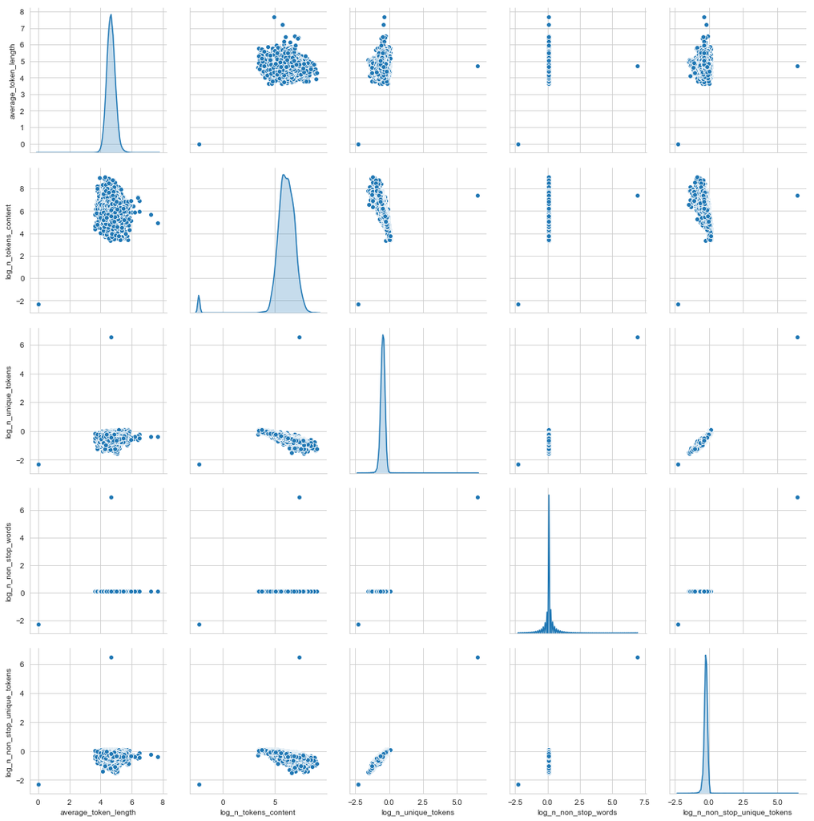

```python
## Highly correlated variables are shown in pairplots

sns.pairplot(df, vars=['average_token_length','log_n_tokens_content','log_n_unique_tokens',
                       'log_n_non_stop_words','log_n_non_stop_unique_tokens'],
             diag_kind="kde", palette="husl", height=3)
```

#### 06_03 Larger subset of highly correlated attributes

Having looked at the heatmap for all the attributes in **06_01** and a subset of natural language attributes in **06_02**, we decided to use a correlation matrix to take a step back again and look at a large subset to see if we could identify any more interesting relationships. The benefit of using the correlation matrix is that it incorporates the visual aspect of a heatmap along with the numerical information found in a correlation table.

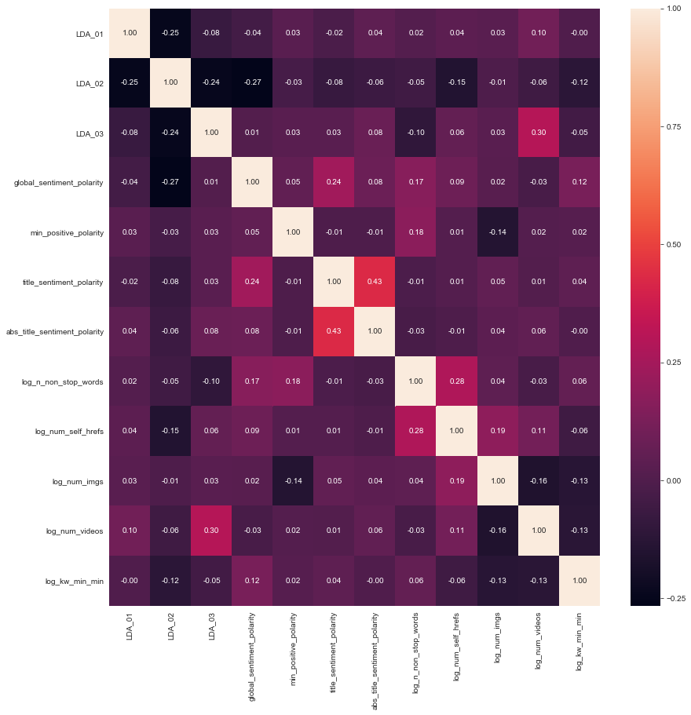

```python
# Plot the correlation matrix using seaborn with the chosen 12 independent variables as mentioned in the Summary Statistics section

df_corr_select= df[['LDA_01', 'LDA_02', 'LDA_03', 'global_sentiment_polarity','min_positive_polarity',
                    'title_sentiment_polarity', 'abs_title_sentiment_polarity', 'log_n_non_stop_words',
                    'log_num_self_hrefs', 'log_num_imgs', 'log_num_videos','log_kw_min_min']]

sns.heatmap(df_corr_select.corr(), annot=True, fmt=".2f")
plt.rcParams["figure.figsize"] = [12,12]
plt.show()
```

#### 06_04 Pairplot for LDA cluster (LDA_01, LDA_02, LDA-03), as grouped by Weekday and Channel

Moving on from simply narrowing down our attributes of interest and looking for collinearity, we wanted to see if we could incorporate some of the categorical attributes such as *Weekday* and *Channel* into our exploration which definitely provided for some interesting insights.

For pairwise relationships among LDA cluster variables (LDA_01, LDA_02, LDA_03), we use seaborn.pairplot function to create a grid of Axes such that each variable in data will by shared in the y-axis across a single row and in the x-axis across a single column. The diagonal Axes are treated differently, drawing a plot to show the univariate distribution of the data for the variable in that column. Here, we also use 'Weekday' and 'Channel' to show the show the subsets of three variables.

In order to compare easily, we use color palette='husl', and kind='reg' parameters to pairplot.

LDA indicates the closeness to LDA topic 0 to LDA topic 4. From the pairplots, we can see basically each topic is negatively correlated with each other for different weekdays and channels. Interestingly, the world channel is highly and negatively correalted with other channels.

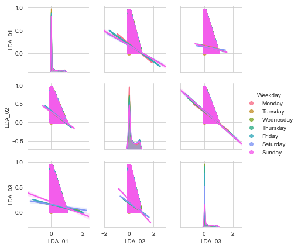

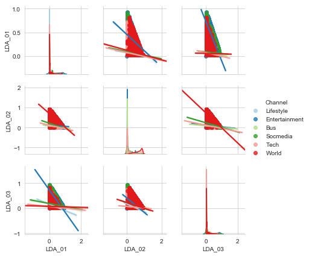

```python
# Pairplot for LDA cluster (LDA_01, LDA_02, LDA-03), as grouped by Weekday and Channel

sns.pairplot(df, vars=['LDA_01', 'LDA_02', 'LDA_03'],
             hue="Weekday", diag_kind="kde", palette="husl", height=2, kind="reg")

sns.pairplot(df, vars=['LDA_01', 'LDA_02', 'LDA_03'],
             hue="Channel", diag_kind="kde", palette="Paired", height=2, kind="reg")
```

#### 06_05 Pairplot for Polarity cluster as grouped by Weekday and Channel

For polarity cluster variabls, they include the polarities for positive and negative words (Avg, Min, Max), text sentiment polarity (global_sentiment_polarity), title polarity (title_sentiment_polarity), the absolute polarity level (abs_title_sentiment_polarity).

From the pairplots, text polarity is positively correlated with words and title in weekdays or channels. However, certain variations can be found. For example, business channel is negatively correalted between text and positive word polarity. The sample distributed normally for these three variables.

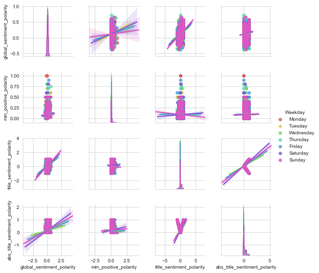

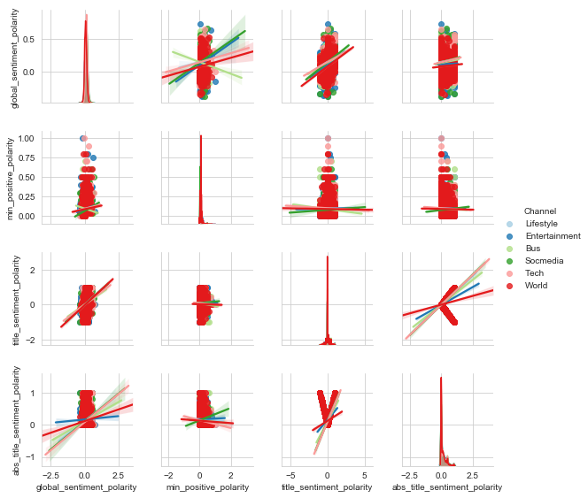

```python
# Pairplot for Polarity cluster as grouped by Weekday and Channel

sns.pairplot(df, vars=['global_sentiment_polarity', 'min_positive_polarity','title_sentiment_polarity',
                       'abs_title_sentiment_polarity',], hue="Weekday", palette="hls", height=2, kind="reg")

sns.pairplot(df, vars=['global_sentiment_polarity', 'min_positive_polarity','title_sentiment_polarity',
                       'abs_title_sentiment_polarity',], hue="Channel", palette="Paired", height=2, kind="reg")
```

#### 06_06 Pairplot for non_stop_words, num_self_hrefs variables as grouped by Weekday and Channel

There are three vraiables in this cluster, 'n_non_stop_words' is the rate of non-stop words in the content , 'num_self_hrefs' is the number of links to other articles published by Mashable, and 'kw_min_min' is the worst keyword (min. shares).

Unexpectively, the worst keyword('kw_min_min') is positively correlated with the rate of non-stop words in the content ('n_non_stop_words') and varies significantly in different weekdays or channels.

Need to figure out the fragmented sample distribution patterns for these three variables.

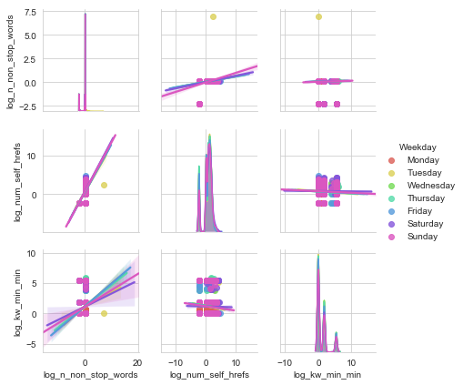

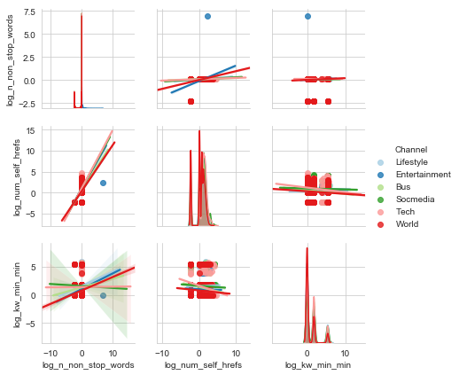

```python
# Pairplot for Non_stop_words and num_self_hrefs variables, as grouped by Weekday and Channel

sns.pairplot(df, vars=['log_n_non_stop_words', 'log_num_self_hrefs', 'log_kw_min_min', ], hue="Weekday", palette="hls", height=2, kind="reg")

sns.pairplot(df, vars=['log_n_non_stop_words', 'log_num_self_hrefs', 'log_kw_min_min', ], hue="Channel", palette="Paired", height=2, kind="reg")
```

#### 06_07 Pairplot for variables num_imgs and num_videos, as grouped by Weekday and Channel

Finally in this section, we would like to check the pairplots with 'num_imgs' (Number of images) and 'num_videos' (Number of videos). It seems the sampe distributions are in clustered peaks. These two variables are negatively correlated either in weekdays or channels.

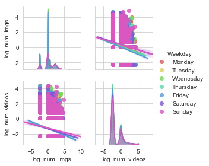

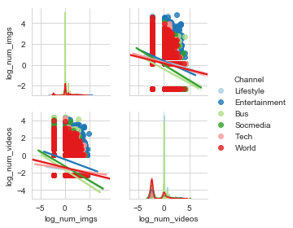

```python
# Pairplot for variables num_imgs and num_videos, as grouped by Weekday and Channel

sns.pairplot(df, vars=['log_num_imgs', 'log_num_videos'], hue="Weekday", palette="hls", height=2, kind="reg")

sns.pairplot(df, vars=['log_num_imgs', 'log_num_videos'], hue="Channel", palette="Paired", height=2, kind="reg")
```

Back to Resubmission Corrections

### 07. Explore Attributes and Class

Back to top

#### Section Objective:

Identify and explain interesting relationships between features and the class you are trying to predict (i.e., relationships with variables and the target classification).*

#### In this section, we have accomplished:

07_01 Target Class Variable - Online News Article Popularity

07_02 Title Sentiment Polarity

07_03 Title Subjectivity

07_04 Number of Embedded Hyperlinks and Associated Social Media Shares

07_05 Number of Videos and Images

#### 07_01 Target Class Variable - Online News Article Popularity

As a reminder, the class that we are predicting is whether an article is popular or not popular based on the cutoff value of 1,400 shares on social media corresponding to the median for the *shares* target attribute. Due to heavy right skewness, we decided to apply a log transformation that results in a normal distribution for this variable that in turn provided better accuracy for our final linear regression model shown at the end of the **Summary Statistics** section. The equivalent cutoff value for the transformed target variable is 7.24 log shares.

Rather than attempting principal component analysis right away, we ran a linear regression model first in an attempt to narrow down the number of attributes when trying to build a prediction model. The list of attributes provided below will be used as a basis for this section to explore how they influence the popularity class attribute.

```python
# list variables included in final regression model at the bottom of the Summary Statistic section
df_ols_endSelection.columns.tolist()
```

```
['LDA_01',
 'LDA_02',
 'LDA_03',
 'global_sentiment_polarity',
 'min_positive_polarity',
 'title_sentiment_polarity',
 'abs_title_sentiment_polarity',
 'log_n_non_stop_words',
 'log_num_self_hrefs',
 'log_num_imgs',
 'log_num_videos',
 'log_kw_min_min',
 'log_shares']
```

#### 07_02 Title Sentiment Polarity

Attributes explored in this sub-section = *title_sentiment_polarity*

From the initial data collection and pre-processing for this dataset carried out by K. Fernandes et al. for their online news popularity [study](https://pdfs.semanticscholar.org/ad7f/3da7a5d6a1e18cc5a176f18f52687b912fea.pdf), it is apparent that they intended to incorporate sentiment analysis into their classification model by including attributes such as *rate_positive_words* and *avg_negative_polarity*. An essential task when performing sentiment analysis is classifying the polarity of a given text at the article, sentence, or even attribute level. The sentiment polarity is a verbal representation of the sentiment which can be 'negative', 'neutral', or 'positive'. The sentiment score is a more precise numerical representation of the sentiment polarity based on a linear score ranging from -1 (negative) to 1 (positive). In more intuitive terms, we are trying to understand the intensity of certain emotions, e.g. joy or anger, invoked by readers when reading the an article.

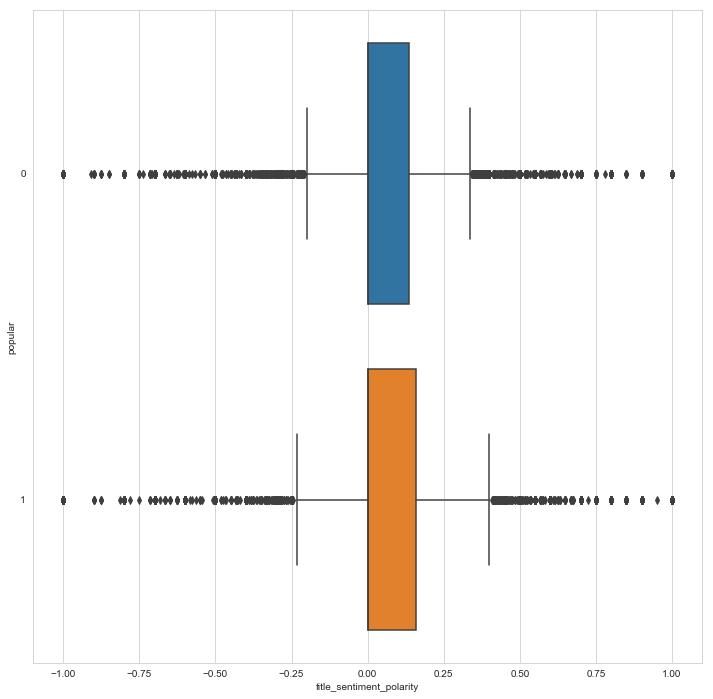

```python
# Horizontal side-by-side boxplot for title sentiment polarity versus article popularity
sns.boxplot(y = "popular", x = "title_sentiment_polarity",  orient = "h", data = dfCopy2)
plt.rcParams["figure.figsize"] = [10,10]
```

#### 07_03 Title Subjectivity

Attributes explored in this sub-section = *title_subjectivity* , *abs_title_subjectivity*

Following on from the sentiment polarity, another attribute typically included in sentiment analysis is subjectivity. As opposed to measuring the readers' emotional response, the subjectivity is related to the personal feelings, views, or beliefs of the publisher and / or author of the article. The subjectivity is commonly defined by classifying a given text, such as a paragraph or a sentence, into one of two classes: objective or subjective. The subjectivity score is a more precise numerical representation of the subjectivity based on a linear score ranging from 0 (objective) to 1 (subjective). It is important to note that measuring subjectivity is more difficult than polarity classification because the subjectivity of words and phrases may depend on their context and an objective article may contain subjective sentences (e.g. a news article quoting people's opinions).

For the *title_subjectivity* attribute we are trying to understand the level of subjectivity in a title while the *abs_title_subjectivity* attribute is a more specific measure of the subjectivity score measured as an absolute difference from 1/2. Similar to comparing the *title_sentiment_polarity* distribution for popular versus unpopular articles in the previous section using side-by-side boxplots, we decided to visualize the distribution for title subjectivity using violin plots.

```
Text(0,0.5,'Absolute Title Subjectivity')
```

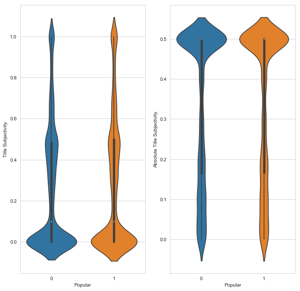

```python
# Violin plot of title subjectivity attribute for both popularity classes
plt.subplot(1, 2, 1)
sns.violinplot(x = "popular", y = "title_subjectivity", data = dfCopy2)
plt.xlabel('Popular')
plt.ylabel('Title Subjectivity')

# Violin plot of absolute title subjectivity attribute for both popularity classes
plt.subplot(1, 2, 2)
sns.violinplot(x = "popular", y = "abs_title_subjectivity", data = dfCopy2)
plt.xlabel('Popular')
plt.ylabel('Absolute Title Subjectivity')
```

Starting with the title subjectivity violin plot on the left hand side, it appears that the distribution is similar for both classes with a large peak centered around a subjectivity score of 0 along with a long tail towards the other end of the scale including a much smaller peak around 0.5 which further thins out at the maximum score of 1. This trend suggests that the majority of articles in the dataset have titles that are objective or partially subjective but seems like the publishers and authors are trying to stay away from using very subjective ones. When looking at plot on the right hand side, the absolute title subjectivity distribution confirms this observation (large peaks at 0.5) by showing that the majority of articles are completely objective when measured as an absolute difference from the half-way point (partial subjectivity).

#### 07_04 Number of Embedded Hyperlinks and Associated Social Media Shares

Attributes explored in this sub-section = *log_num_hrefs* , *log_num_self_hrefs*, *log_self_reference_avg_sharess*

This dataset was originally created as part of a [study](https://pdfs.semanticscholar.org/ad7f/3da7a5d6a1e18cc5a176f18f52687b912fea.pdf) carried out by K. Fernandes et al. to come up with a prediction model for online news popularity. An interesting attribute that they decided to explore was the number of hyperlinks (*num_hrefs*) embedded in each article prior to publication with the purpose of evaluating the keywords within those referenced articles and the corresponding popularity as measured by the number of shares on social media (*self_reference_avg_shares*). These embedded links are then scored on a worst / average / best basis relative to the success rate of the keywords labelled as *kw_min_min* or *kw_max_avg* for example.

The overarching goal for this process was to figure out a way use the worst and best keywords from published articles as an estimator for the number of social media shares for articles that have not yet been published. We also believe that they were trying to see whether embedding links to popular published articles would influence the popularity of an article of interest. Since this study was focused on articles published by Mashable, it seemed logical for the authors to create a separate attribute measuring the number of embedded hyperlinks that referenced published articles on their website (*num_self_hrefs*).

Since the number of embedded hyperlinks and corresponding social media shares had highly right skewed distributions, we applied a log transformation to these attributes as outlined in the **Data Quality** section. To get a feel for how these attributes influence the popularity class of online news articles in our dataset, we decided to use scatter plots along with a simple regression line for each class.

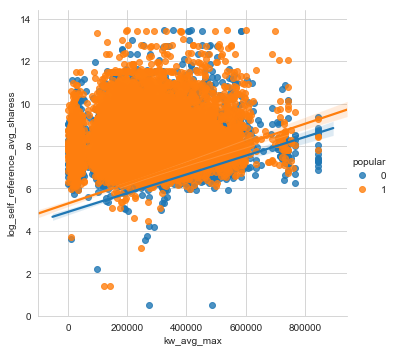

```python
# Scatter plot showing kw_avg_max versus log_self_reference_avg_shares with regression lines for both popularity classes
lm = sns.lmplot(x = "kw_avg_max", y = "log_self_reference_avg_sharess", hue = "popular", data = dfCopy2)
lm.set(ylim = (0, None))
```

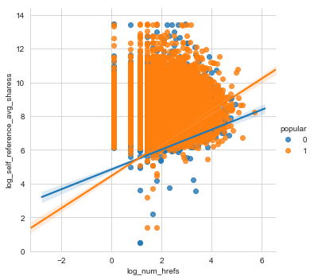

```python
# Scatter plot showing log_num_hrefs versus log_self_reference_avg_shares with regression lines for both popularity classes
lm_hrefs = sns.lmplot(x = "log_num_hrefs", y = "log_self_reference_avg_sharess", hue = "popular", data = dfCopy2)
lm_hrefs.set(ylim = (0, None))
```

The next relationship we wanted to explore was how the log number of average social media shares for published articles changed with the log number of embedded links referencing those articles as shown in the scatter plot above. It seemed logical that inlcuding more hyperlinks in an article would increase the likelihood of yielding a larger number of shares for the articles referenced in those hyperlinks. However, we found it interesting that there is a greater influence on the popular article class as shown by the steeper slope of its regression line. With such an obvious difference between the two classes, we think that these two attributes will be important to keep in our classification model as they could potentially have a strong effect on its predictive power.

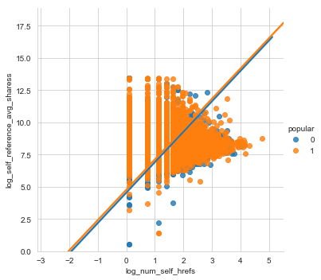

```python
# Scatter plot showing log_num_self_hrefs versus log_self_reference_avg_shares with regression lines for both popularity classes
lm_hrefs = sns.lmplot(x = "log_num_self_hrefs", y = "log_self_reference_avg_sharess", hue = "popular", data = dfCopy2)
lm_hrefs.set(ylim = (0, None))
```

We also wanted to explore the same relationship with a more specific focus on embedded hyperlinks referencing only Mashable articles. The scatter plot above doesn't show any obvious deviations in the regression lines between the popularity classes so we will have to further investigate whether the *log_num_self_hrefs* will be worth keeping in our model.

#### 07_05 Number of Videos and Images

Attributes explored in this sub-section = *log_num_imgs* , *log_num_imgs*

The modern readers' attention span is decreasing every year and most [studies](https://blog.bufferapp.com/55-visitors-read-articles-15-seconds-less-focus-attention-not-clicks) are estimating the average time spent reading an online article at less than 15 seconds. With this in mind, it would seem that authors and publishers alike would be looking for ways to condense the contents of an article into an easy to digest picture or a quick video.

In the **Explore Joint Attributes** section, it was interesting to see on the first correlation matrix that there is a weak negative (Pearson's r = -0.16) relationship between the log number of images and the log number of videos. It would seem that images and videos typically complement each other in articles and there would be somewhat of a positive relationship, however, to avoid overcrowding an article, it does make sense to have less videos embedded as more images are added and vice versa.

Since we already explored how the distribution for the log number of embedded photos and videos for popular / unpopular articles differed as a function of the data channel it belonged to (lifestyle, technology etc.) using violin plots, we decided to look at the *Weekday* attribute instead.

```
Text(0,0.5,'Log Number of Images')
```

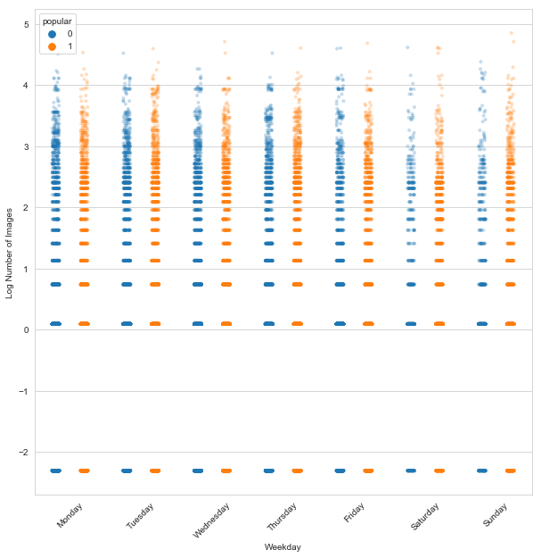

```python
# Strip plot of popular versus unpopular articles measured by log_num_images categorized by Weekday
sns.stripplot(x = "Weekday", y = "log_num_imgs", hue = "popular", dodge = True, jitter = True, alpha = 0.25, zorder = 1, size = 4, data = dfCopy2)
plt.xlabel('Weekday')
plt.xticks(rotation = 45)
plt.ylabel('Log Number of Images')
```

```
Text(0,0.5,'Log Number of Videos')
```

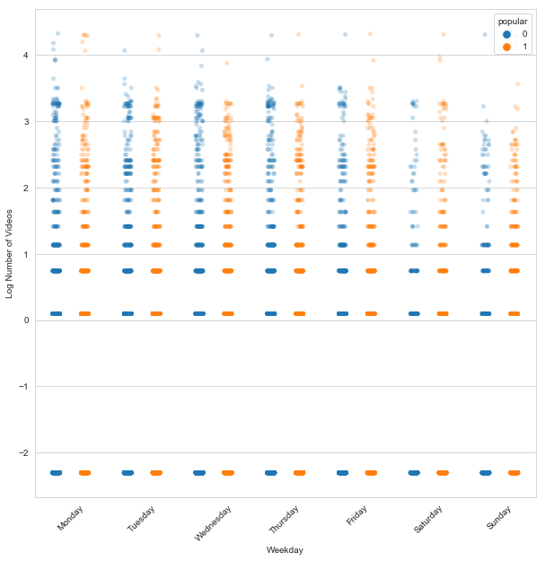

```python
# Strip plot of popular versus unpopular articles measured by log_num_videos categorized by Weekday
sns.stripplot(x = "Weekday", y = "log_num_videos", hue = "popular", dodge = True, jitter = True, alpha = 0.25, zorder = 1, size = 5,  data = dfCopy2)
plt.xlabel('Weekday')
plt.xticks(rotation = 45)
plt.ylabel('Log Number of Videos')
```

Going forward, when refining our classification model, it will be important to understand this relationship and to invesigate which of the two attribute has a stronger influence on the predictive power of the model.

Back to Resubmission Corrections

### 08. New Features

Back to top

#### Section Objective:

Are there other features that could be added to the data or created from existing features? Which ones?

##### Suggested additions to the dataset

1. Break down the number of shares per social media channel
   - This would be intersting because it would allow for analysis to be perfomred to see if an article will be popular on each social media channel. Knowing how the attributes of an article will affect its popularity one each social media platform would allow the publisher to tailor article to the desired platform or even creation social media channel specifc variation of an article to increase pupularity on each channel.
2. Capture the number of hashtags applied to the article
   - Hashtags play a large role in making a topic trend on social media and getting something like an article to go viral. It would make sense to capture information about hashtags in the dataset to see if they
3. Introduction of time series
   - Capturing the number of shares an article is reciveing of a set of time intervals would allow publishers to see trends and set benchmarks for pupularity of an article. If a pubisher were ablt to see that an article has only gained so much attention at regular intervals it would be helpful for them to know if they need to introduce another article around that same subject or category or if the article is still gaining traction to let it continue to grow before introducing more articles that might impact the popularity of the first.
4. To analyze and check articles published by other publishers besides Mashable
5. To analyze and classfiy traditional articles rahter than only from Mashable
6. Make better article assesment methods, such as contentlike trend analysis
7. Integrate source information, potential reach, and possible competition for attention

### 09. Exceptional Work

Back to top

#### Section Objective:

You have free reign to provide additional analyses. One idea: implement dimensionality reduction, then visualize and interpret the results.*

#### In this section, we have accomplished:

09_01 Use Recursive Feature Elimination (RFE) for Feature Selection

09_02 Feature selection with Linear Model (LM) and Random Forest(RF)

09_02_01 Linear Model (LM) Feature Ranking

09_02_02 Random Forest (RF) feature ranking

09_02_03 Rank and plot the feature with the mean values calculated from all the scores from RFE, LM and RF

09_03 Compare prediction model accuracy

09_03_01 Logistic regression without considering individual variable weight (model accuracy = 0.57)

09_03_02 Logistic regression with considering individual variable weight (model accuracy = 0.64)

09_03_03 Support Vector Mechine (SVM) method (model accuracy = 0.66)

Initially when attempting to build a classification model for this data set, we noticed that our accuracy was low, averaging less than 0.5, so we decided to swtich our focus to building a prediction model using *log_shares* as our target variable.

#### 09_01 Use Recursive Feature Elimination (RFE) for Feature Selection

Feature selection before modeling is a process to select either the best or the worst performing features. It will help eliminate the irrelevant features in the dataset, improve the model accuracy, reduce overfitting and training time.

```python
# Drop 2 categorical varaibles and 'popular' as created above
df = df.drop(['Channel', 'Weekday', 'popular'], axis=1)
```

```python
# Define ranking dictionary and function

from sklearn.preprocessing import MinMaxScaler

ranks = {}

def ranking(ranks, names, order=1):
    minmax = MinMaxScaler()
    ranks = minmax.fit_transform(order*np.array([ranks]).T).T[0]
    ranks = map(lambda x: round(x,2), ranks)
    return dict(zip(names, ranks))
```

```python
# Recursive Feature Elimination (RFE)

from sklearn.feature_selection import RFE
from sklearn.linear_model import LogisticRegression

## Change numerical varaible 'log_shares' to categorical variable 'log_shares_cut' (0 =unpopular, 1=popular)
df['log_shares_cut'] = pd.qcut(df['log_shares'], 2, labels = ('0', '1'))
df = df.drop(['log_shares'], axis=1) # Drop variable'log_shares'

# create a base classifier used for evaluating a subset of attributes
model_logit = LogisticRegression()

# create the RFE model and select 10 attributes
rfe = RFE(model_logit, n_features_to_select=10)
rfe = rfe.fit(df, df.log_shares_cut)

# summarize the selection of the attributes
colnames = df.columns
ranks["RFE"] = ranking(list(map(float, rfe.ranking_)), colnames, order=-1)
print(ranks["RFE"])
```

[output not shown]

#### 09_02 Feature selection with Linear Model (LM) and Random Forest(RF)

From the feature selection process, we use LM (linear regression, ridge, and lasso), rank forest to rank the variables and plot together with RFE scores.

Finally, the top important variables are identified as: LDA cluster (LDA_01, _02, _03, _04), polarity cluster including global_sentiment_polarity, words and hrefs. This result is comparable as we analyzied in Section 6 and the only exceptions are the variables related to imgs and videos.

For this part of work, we modified the codes to fit our online news popularity dataset from Anisotropic on topic "Feature Ranking RFE, Random Forest, linear models" (https://www.kaggle.com/arthurtok/feature-ranking-rfe-random-forest-linear-models ).

#### 09_02_01 Linear Model (LM) Feature Ranking

```python
# Feature ranking with LinearRegression, Ridge, Lasso

from sklearn.linear_model import (LinearRegression, Ridge, Lasso)

# Linear Regression
lr = LinearRegression(normalize=True)
lr.fit(class_X,class_y)
ranks["LinReg"] = ranking(np.abs(lr.coef_), colnames)

# Ridge
ridge = Ridge(alpha = 7)
ridge.fit(class_X,class_y)
ranks['Ridge'] = ranking(np.abs(ridge.coef_), colnames)

# Lasso
lasso = Lasso(alpha=.05)
lasso.fit(class_X, class_y)
ranks["Lasso"] = ranking(np.abs(lasso.coef_), colnames)
```

#### 09_02_02 Random Forest (RF) feature ranking¶

```python
# Feature ranking with Random Forest Regression

from sklearn.ensemble import RandomForestRegressor

rf = RandomForestRegressor(n_jobs=-1, n_estimators=45, verbose=3)
rf.fit(class_X,class_y)
ranks["RF"] = ranking(rf.feature_importances_, colnames);
```

[output not shown]

```
[Parallel(n_jobs=-1)]: Done  16 tasks      | elapsed:   17.7s
```

[output not shown]

```
[Parallel(n_jobs=-1)]: Done  45 out of  45 | elapsed:   32.6s finished
```

#### 09_02_03 Rank and plot the feature with the mean values calculated from all the scores from RFE, LM and RF

```python
# Create empty dictionary to store the mean value calculated from all the scores

r = {}

for name in colnames:
    r[name] = round(np.mean([ranks[method][name]
                             for method in ranks.keys()]), 2)

methods = sorted(ranks.keys())
ranks["Mean"] = r
methods.append("Mean")

print("\t%s" % "\t".join(methods))

for name in colnames:
    print("%s\t%s" % (name, "\t".join(map(str, [ranks[method][name] for method in methods]))))

# Put the mean scores into a Pandas dataframe
meanplot = pd.DataFrame(list(r.items()), columns= ['Feature','Mean Ranking'])

# Sort the dataframe
meanplot = meanplot.sort_values('Mean Ranking', ascending=False)
```

```
	Lasso	LinReg	RF	RFE	Ridge	Mean
n_tokens_title	0.0	0.0	0.0	0.66	0.0	0.13
average_token_length	0.0	0.0	0.24	1.0	0.0	0.25
num_keywords	0.0	0.04	0.39	0.34	0.15	0.18
kw_max_max	0.51	0.01	0.07	0.0	0.05	0.13
kw_avg_max	0.0	0.0	0.13	0.03	0.0	0.03
kw_min_avg	0.0	0.0	0.44	0.06	0.0	0.1
LDA_00	0.01	0.0	0.23	0.74	0.0	0.2
LDA_01	0.0	0.8	0.37	1.0	0.41	0.52
LDA_02	0.0	1.0	0.41	1.0	0.34	0.55
LDA_03	0.0	0.99	0.38	1.0	0.31	0.54
LDA_04	0.0	0.96	0.37	0.6	0.19	0.42
global_subjectivity	0.0	0.81	0.46	0.31	0.37	0.39
global_sentiment_polarity	0.0	0.23	0.38	0.23	0.84	0.34
global_rate_positive_words	0.0	0.05	0.32	0.09	0.16	0.12
global_rate_negative_words	0.0	0.14	0.34	0.26	0.4	0.23
rate_positive_words	0.0	0.48	0.28	0.97	0.26	0.4
rate_negative_words	0.0	0.3	0.14	1.0	0.29	0.35
avg_positive_polarity	0.0	0.21	0.16	0.8	0.05	0.24
min_positive_polarity	0.0	0.03	0.34	0.71	0.13	0.24
max_positive_polarity	0.0	0.13	0.14	0.49	0.47	0.25
avg_negative_polarity	0.0	0.02	0.11	0.4	0.05	0.12
min_negative_polarity	0.0	0.04	0.31	0.43	0.14	0.18
max_negative_polarity	0.0	0.02	0.13	0.46	0.09	0.14
title_subjectivity	0.0	0.03	0.17	0.11	0.11	0.08
title_sentiment_polarity	0.0	0.03	0.14	0.63	0.1	0.18
abs_title_subjectivity	0.0	0.04	0.17	0.69	0.13	0.21
abs_title_sentiment_polarity	0.0	0.07	0.13	0.14	0.25	0.12
log_n_tokens_content	0.0	0.03	0.12	0.51	0.1	0.15
log_n_unique_tokens	0.0	0.05	0.35	1.0	0.15	0.31
log_n_non_stop_words	0.0	0.35	0.36	1.0	1.0	0.54
log_n_non_stop_unique_tokens	0.0	0.1	0.0	1.0	0.56	0.33
log_num_hrefs	0.0	0.14	0.35	0.94	0.33	0.35
log_num_self_hrefs	0.0	0.05	0.33	0.37	0.16	0.18
log_num_imgs	0.0	0.02	0.15	0.57	0.07	0.16
log_num_videos	0.0	0.01	0.19	0.54	0.03	0.15
log_kw_min_min	0.01	0.02	0.13	0.29	0.08	0.11
log_kw_max_min	0.0	0.0	0.04	0.89	0.02	0.19
log_kw_avg_min	0.27	0.03	0.29	0.91	0.12	0.32
log_kw_min_max	0.0	0.06	0.34	0.17	0.22	0.16
log_kw_max_avg	1.0	0.03	0.18	0.77	0.1	0.42
log_kw_avg_avg	0.0	0.01	0.53	1.0	0.05	0.32
log_self_reference_min_shares	0.0	0.06	1.0	0.2	0.23	0.3
log_self_reference_max_shares	0.0	0.03	0.33	0.83	0.11	0.26
log_self_reference_avg_sharess	0.0	0.09	0.21	0.86	0.32	0.3
log_shares_cut	0.26	0.13	0.52	1.0	0.49	0.48
```

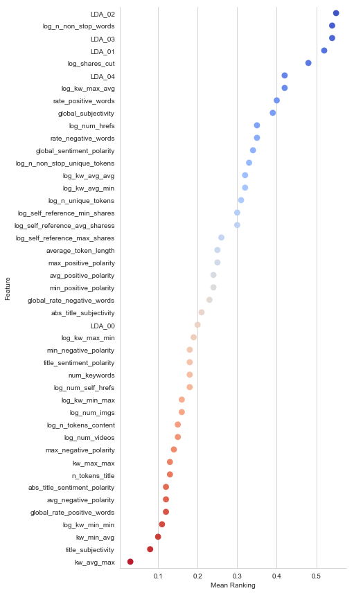

```python
# Let's plot the ranking of the features
sns.catplot(x="Mean Ranking", y="Feature", data = meanplot, kind="point",
               height=12, aspect=0.6, palette='coolwarm')
```

#### Feature selection process summary

From the feature selection process, we find the top important variables are LDA cluster (LDA_01, _02, _03, _04), polarity cluster including global_sentiment_polarity, words and hrefs. This result is comparable as we analyzied in Section 6 and the only exceptions are the variables related to imgs and videos.

#### 09_03 Compare prediction model accuracy

In your comments, you concern about the low prediction accuracy 73% as cited from Refernce 2.

It would be interesting to explore what the best model prediction accuracy would be by using logistic regression (with and without variable weight interpretation) and support vector mechine (SVM) methods.

For this part of work, we modified the codes to fit our online news popularity dataset from DataMingNotebooks/04 on topic "Logistic Regression, SVMs, and Gradient Optimization" (https://github.com/eclarson/DataMiningNotebooks/blob/master/04.%20Logits%20and%20SVM.ipynb ).

The results show that the SVM method with accuracy at 0.66 is superior to logistic regression methods (0.57 and 0.64).

In the coming project, we will look for more accurate prediction models and try to beat 73% accuracy in literature.

##### 09_03_01 Logistic regression without considering individual variable weight (model accuracy = 0.57)

```python
# Training and testing splits

from sklearn.model_selection import ShuffleSplit

if 'log_shares_cut' in df:
    y = df['log_shares_cut'].values
    del df['log_shares_cut']
    X = df.values
    num_cv_iterations = 3
    num_instances = len(y)
    cv_object = ShuffleSplit(n_splits=num_cv_iterations, test_size  = 0.2)

print(cv_object)
```

```
ShuffleSplit(n_splits=3, random_state=None, test_size=0.2, train_size=None)
```

```python
# logistic regression accuracy is around 0.57

from sklearn.linear_model import LogisticRegression
from sklearn import metrics as mt

lr_clf = LogisticRegression(penalty='l2', C=1.0, class_weight=None)
iter_num=0

for train_indices, test_indices in cv_object.split(X,y):

    X_train = X[train_indices]
    y_train = y[train_indices]

    X_test = X[test_indices]
    y_test = y[test_indices]

    # train the reusable logisitc regression model on the training data
    lr_clf.fit(X_train,y_train)  # train object
    y_hat = lr_clf.predict(X_test) # get test set precitions

    # get the accuracy and confusion matrix for this iterations of training/testing
    acc = mt.accuracy_score(y_test,y_hat)
    conf = mt.confusion_matrix(y_test,y_hat)
    print("====Iteration",iter_num," ====")
    print("accuracy", acc )
    print("confusion matrix\n",conf)
    iter_num+=1
```

```
====Iteration 0  ====
accuracy 0.5663980901223515
confusion matrix
 [[2668  852]
 [2054 1128]]
====Iteration 1  ====
accuracy 0.5614741868099075
confusion matrix
 [[2678  889]
 [2050 1085]]
====Iteration 2  ====
accuracy 0.5680393912264996
confusion matrix
 [[2705  895]
 [2000 1102]]
```

##### 09_03_02 Logistic regression with considering individual variable weight (model accuracy = 0.64)

```python
## Weight interpretation and improved accuracy to 0.65 after normalizing the features with StandardScaler

from sklearn.preprocessing import StandardScaler

# scale attributes by the training set
scl_obj = StandardScaler()
scl_obj.fit(X_train) # scalings to transform new feature data

X_train_scaled = scl_obj.transform(X_train) # apply to training
X_test_scaled = scl_obj.transform(X_test) # apply those means and std to the test set

# train the model just as before
lr_clf = LogisticRegression(penalty='l2', C=0.05) # 'C' value is 0.05 here
lr_clf.fit(X_train_scaled,y_train)  # train object

y_hat = lr_clf.predict(X_test_scaled) # get test set precitions

acc = mt.accuracy_score(y_test,y_hat)
conf = mt.confusion_matrix(y_test,y_hat)
print('accuracy:', acc )
print(conf )

# sort these attributes and spit them out
zip_vars = zip(lr_clf.coef_.T,df.columns) # combine attributes
zip_vars = sorted(zip_vars)
for coef, name in zip_vars:
    print(name, 'has weight of', coef[0]) # now print them out
```

```
accuracy: 0.6386153387048642
[[2485 1115]
 [1307 1795]]
log_kw_min_max has weight of -0.651291538826776
log_n_unique_tokens has weight of -0.357428388978285
log_kw_max_min has weight of -0.2174110268465491
log_self_reference_max_shares has weight of -0.2076455355855795
log_n_tokens_content has weight of -0.1929963264417858
kw_max_max has weight of -0.16626394946224823
LDA_01 has weight of -0.15981313650328965
log_kw_max_avg has weight of -0.15047117291582657
LDA_02 has weight of -0.1380124654983034
log_num_self_hrefs has weight of -0.12630232922406656
LDA_03 has weight of -0.10376140274358658
rate_negative_words has weight of -0.08800837664122732
average_token_length has weight of -0.07026636841273422
avg_positive_polarity has weight of -0.03960739056874408
min_positive_polarity has weight of -0.03539884744794261
log_kw_min_min has weight of -0.03258295834194492
min_negative_polarity has weight of -0.025715614110297862
n_tokens_title has weight of -0.025068148597312677
rate_positive_words has weight of -0.011876862917128531
abs_title_sentiment_polarity has weight of -0.007455896108640818
global_sentiment_polarity has weight of -0.0051049145551167584
kw_avg_max has weight of 0.0021201299994803445
global_rate_positive_words has weight of 0.004050669504214074
max_positive_polarity has weight of 0.0070026097948185035
avg_negative_polarity has weight of 0.013740603504556472
max_negative_polarity has weight of 0.01610775386936911
global_rate_negative_words has weight of 0.0374296543304105
abs_title_subjectivity has weight of 0.051681535289641846
title_subjectivity has weight of 0.053009890184264385
title_sentiment_polarity has weight of 0.05629909497055414
log_num_imgs has weight of 0.06563000180042473
log_num_videos has weight of 0.0759529949175215
log_self_reference_min_shares has weight of 0.07946930651840843
global_subjectivity has weight of 0.10283506389001577
num_keywords has weight of 0.12216341431170363
LDA_00 has weight of 0.12569594801090775
LDA_04 has weight of 0.12573910471371233
log_n_non_stop_unique_tokens has weight of 0.14003563457716295
log_num_hrefs has weight of 0.1492372049018235
log_n_non_stop_words has weight of 0.2291084750329662
log_kw_avg_min has weight of 0.27881397456793183
log_self_reference_avg_sharess has weight of 0.33358600274116484
log_kw_avg_avg has weight of 0.47138757527842423
kw_min_avg has weight of 0.684829381375333
```

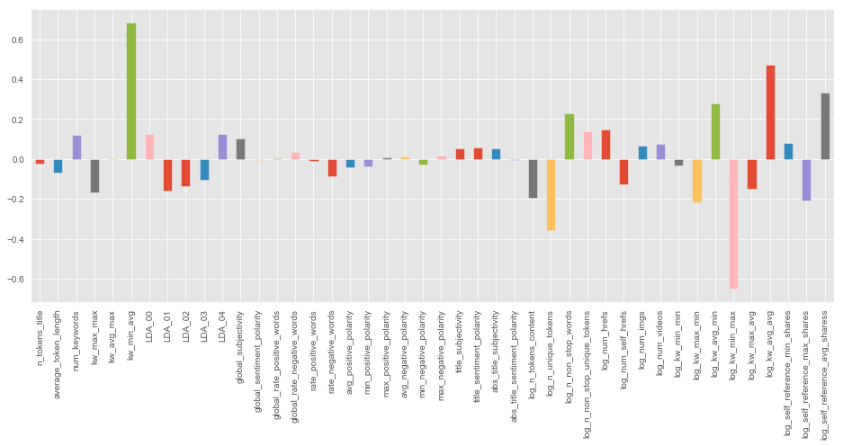

```python
# Make a pandas Series with the names and values, and plot them
from matplotlib import pyplot as plt
%matplotlib inline
plt.style.use('ggplot')
plt.figure(figsize=(16,6))
weights = pd.Series(lr_clf.coef_[0],index=df.columns)
weights.plot(kind='bar')
plt.show()
```

##### 09_03_03 Support Vector Mechine (SVM) method (model accuracy = 0.66)

```python
# Run through the cross validation loop and set the training and testing variable for one single iteration

for train_indices, test_indices in cv_object.split(X,y):

    X_train = X[train_indices]
    y_train = y[train_indices]

    X_test = X[test_indices]
    y_test = y[test_indices]

X_train_scaled = scl_obj.transform(X_train) # apply to training
X_test_scaled = scl_obj.transform(X_test)
```

```python
# Investigate SVMs on the data and play with the parameters and kernels

from sklearn.svm import SVC

# train the model just as before
svm_clf = SVC(C=0.5, kernel='rbf', degree=3, gamma='auto') # get object
svm_clf.fit(X_train_scaled, y_train)  # train object

y_hat = svm_clf.predict(X_test_scaled) # get test set precitions

acc = mt.accuracy_score(y_test,y_hat)
conf = mt.confusion_matrix(y_test,y_hat)
print('accuracy:', acc )
print(conf)
```

```
accuracy: 0.6568188600417786
[[2545  958]
 [1342 1857]]
```

Back to Resubmission Corrections

### Resource and Reference

1. Online News Popularity Dataset from UCI Machine Learning Repository: https://archive.ics.uci.edu/ml/datasets/Online+News+Popularity
2. Kelwin Fernandes, Pedro Vinagre, and Paulo Cortez. A Proactive Intelligent Decision Support System for Predicting the Popularity of Online News (https://pdfs.semanticscholar.org/ad7f/3da7a5d6a1e18cc5a176f18f52687b912fea.pdf)